# Capstone (2)

## Problem Stemement

**Input** **Description**

**Train/Test** : Whether the data belongs to the train set or test set

**ID** : A unique ID to identify a candidate

**Salary** : Annual CTC offered to the candidate (in INR)

**Gender** : Candidate's gender

**DOB** : Date of birth of candidate

**10percentage** : Overall marks obtained in grade 10 examinations

**10board** : The school board whose curriculum the candidate followed in grade 10

**12graduation** : Year of graduation - senior year high school

**12percentage** : Overall marks obtained in grade 12 examinations

**12board** : The school board whose curriculum the candidate followed

**CollegeID** : Unique ID identifying the university/college which the candidate attended for her/his undergraduate

**CollegeTier** : Each college has been annotated as 1 or 2. The annotations have been computed from the average AMCAT scores obtained by the students in the college/university. Colleges with an average score above a threshold as tagged as 1 and others as 2.

**Degree** : Degree obtained/pursued by the candidate

**Specialization** : Specialization pursued by the candidate

**CollegeGPA** : Aggregate GPA at graduation

**CollegeCityID** : A unique ID to identify the city in which the college is located in.

**CollegeCityTier** : The tier of the city in which the college is located in. This is annotated based on the population of the cities.

**CollegeState** : Name of the state in which the college is located

**GraduationYear** : Year of graduation (Bachelor's degree)

**English** : Scores in AMCAT English section

**Logical** : Score in AMCAT Logical ability section

**Quant** : Score in AMCAT's Quantitative ability section

**Domain** : Scores in AMCAT's domain module

**ComputerProgramming** : Score in AMCAT's Computer programming section

**ElectronicsAndSemicon** : Score in AMCAT's Electronics & Semiconductor Engineering section

**ComputerScience** : Score in AMCAT's Computer Science section

**MechanicalEngg** : Score in AMCAT's Mechanical Engineering section

**ElectricalEngg** : Score in AMCAT's Electrical Engineering section

**TelecomEngg** : Score in AMCAT's Telecommunication Engineering section

**CivilEngg** : Score in AMCAT's Civil Engineering section

**conscientiousness** : Scores in one of the sections of AMCAT's personality test

**agreeableness** : Scores in one of the sections of AMCAT's personality test

**extraversion** : Scores in one of the sections of AMCAT's personality test

**nueroticism** : Scores in one of the sections of AMCAT's personality test

**openess_to_experience** : Scores in one of the sections of AMCAT's personality test

```python
import numpy as np
import pandas as pd
from warnings import filterwarnings
filterwarnings('ignore')

import matplotlib.pyplot as plt
%matplotlib inline
import seaborn as sns
plt.rcParams['figure.figsize']=15,8

# display all columns of the dataframe
pd.options.display.max_columns = None

# display all rows of the dataframe
pd.options.display.max_rows = None
# to display the float values upto 4 decimal places
pd.options.display.float_format = '{:.5f}'.format

from sklearn.preprocessing import StandardScaler,MinMaxScaler

from sklearn.model_selection import train_test_split,GridSearchCV

from sklearn.linear_model import LinearRegression
from sklearn.tree import DecisionTreeRegressor
from sklearn.ensemble import RandomForestRegressor

from sklearn.metrics import mean_squared_error,mean_absolute_error,r2_score

from mlxtend.feature_selection import SequentialFeatureSelector as sfs
from sklearn.feature_selection import RFE

import statsmodels.api as sm
import statsmodels.stats.api as sms
from statsmodels.stats.outliers_influence import variance_inflation_factor
from statsmodels.graphics.gofplots import qqplot
from statsmodels.stats.anova import anova_lm
from statsmodels.formula.api import ols
from sklearn.model_selection import train_test_split
```

**Importing the data**

```python
train_data =pd.read_excel( 'train.xlsx')

train_data.head()
```

|  | Unnamed: 0 | ID | Salary | Gender | DOB | 10percentage | 10board | 12graduation | 12percentage | 12board | CollegeID | CollegeTier | Degree | Specialization | collegeGPA | CollegeCityID | CollegeCityTier | CollegeState | GraduationYear | English | Logical | Quant | Domain | ComputerProgramming | ElectronicsAndSemicon | ComputerScience | MechanicalEngg | ElectricalEngg | TelecomEngg | … |
| --- | --- | --- | --- | --- | --- | --- | --- | --- | --- | --- | --- | --- | --- | --- | --- | --- | --- | --- | --- | --- | --- | --- | --- | --- | --- | --- | --- | --- | --- | --- |
| 0 | train | 203097 | 420000 | f | 1990-02-19 | 84.30000 | board ofsecondary education,ap | 2007 | 95.80000 | board of intermediate education,ap | 1141 | 2 | B.Tech/B.E. | computer engineering | 78.00000 | 1141 | 0 | Andhra Pradesh | 2011 | 515 | 585 | 525 | 0.63598 | 445 | -1 | -1 | -1 | -1 | -1 | … |
| 1 | train | 579905 | 500000 | m | 1989-10-04 | 85.40000 | cbse | 2007 | 85.00000 | cbse | 5807 | 2 | B.Tech/B.E. | electronics and communication engineering | 70.06000 | 5807 | 0 | Madhya Pradesh | 2012 | 695 | 610 | 780 | 0.96060 | -1 | 466 | -1 | -1 | -1 | -1 | … |
| 2 | train | 810601 | 325000 | f | 1992-08-03 | 85.00000 | cbse | 2010 | 68.20000 | cbse | 64 | 2 | B.Tech/B.E. | information technology | 70.00000 | 64 | 0 | Uttar Pradesh | 2014 | 615 | 545 | 370 | 0.45088 | 395 | -1 | -1 | -1 | -1 | -1 | … |
| 3 | train | 267447 | 1100000 | m | 1989-12-05 | 85.60000 | cbse | 2007 | 83.60000 | cbse | 6920 | 1 | B.Tech/B.E. | computer engineering | 74.64000 | 6920 | 1 | Delhi | 2011 | 635 | 585 | 625 | 0.97440 | 615 | -1 | -1 | -1 | -1 | -1 | … |
| 4 | train | 343523 | 200000 | m | 1991-02-27 | 78.00000 | cbse | 2008 | 76.80000 | cbse | 11368 | 2 | B.Tech/B.E. | electronics and communication engineering | 73.90000 | 11368 | 0 | Uttar Pradesh | 2012 | 545 | 625 | 465 | 0.12450 | -1 | 233 | -1 | -1 | -1 | -1 | … |

**Checking the shape of the data**

```python
train_data.shape
```

```
(3998, 35)
```

### Making necessary Assumptions and changes accordingly

**1. We use salary as our dependent variable.**

**2. We don`t need CollegeId and CollegeCityID atributes. And it is perfectly safe to drop them. Because we already have a unique ID for every candidate.**

**3. We would encode the numerical attributes and categorical attributes and stack them to create our feature vector.**

```python
df=train_data.drop(columns=['Unnamed: 0','CollegeID','CollegeCityID'],axis=1)
```

**Checking the shape after removing the insignificant variable**

```python
df.shape
```

```
(3998, 32)
```

**Checking the info :Data types,and nulls present in the data**

```python
df.info()
```

```
<class 'pandas.core.frame.DataFrame'>
RangeIndex: 3998 entries, 0 to 3997
Data columns (total 32 columns):
 #   Column                 Non-Null Count  Dtype
---  ------                 --------------  -----
 0   ID                     3998 non-null   int64
 1   Salary                 3998 non-null   int64
 2   Gender                 3998 non-null   object
 3   DOB                    3998 non-null   datetime64[ns]
 4   10percentage           3998 non-null   float64
 5   10board                3998 non-null   object
 6   12graduation           3998 non-null   int64
 7   12percentage           3998 non-null   float64
 8   12board                3998 non-null   object
 9   CollegeTier            3998 non-null   int64
```

[output cut: 24 more lines]

### Statistical Summary of the Variables of data

**Numerical Variables**

```python
df.describe().T
```

|  | count | mean | std | min | 25% | 50% | 75% | max |
| --- | --- | --- | --- | --- | --- | --- | --- | --- |
| ID | 3998.00000 | 663794.54052 | 363218.24583 | 11244.00000 | 334284.25000 | 639600.00000 | 990480.00000 | 1298275.00000 |
| Salary | 3998.00000 | 307699.84992 | 212737.49996 | 35000.00000 | 180000.00000 | 300000.00000 | 370000.00000 | 4000000.00000 |
| 10percentage | 3998.00000 | 77.92544 | 9.85016 | 43.00000 | 71.68000 | 79.15000 | 85.67000 | 97.76000 |
| 12graduation | 3998.00000 | 2008.08754 | 1.65360 | 1995.00000 | 2007.00000 | 2008.00000 | 2009.00000 | 2013.00000 |
| 12percentage | 3998.00000 | 74.46637 | 10.99993 | 40.00000 | 66.00000 | 74.40000 | 82.60000 | 98.70000 |
| CollegeTier | 3998.00000 | 1.92571 | 0.26227 | 1.00000 | 2.00000 | 2.00000 | 2.00000 | 2.00000 |
| collegeGPA | 3998.00000 | 71.48617 | 8.16734 | 6.45000 | 66.40750 | 71.72000 | 76.32750 | 99.93000 |
| CollegeCityTier | 3998.00000 | 0.30040 | 0.45849 | 0.00000 | 0.00000 | 0.00000 | 1.00000 | 1.00000 |
| GraduationYear | 3998.00000 | 2012.10580 | 31.85727 | 0.00000 | 2012.00000 | 2013.00000 | 2014.00000 | 2017.00000 |
| English | 3998.00000 | 501.64907 | 104.94002 | 180.00000 | 425.00000 | 500.00000 | 570.00000 | 875.00000 |
| Logical | 3998.00000 | 501.59880 | 86.78330 | 195.00000 | 445.00000 | 505.00000 | 565.00000 | 795.00000 |
| Quant | 3998.00000 | 513.37819 | 122.30233 | 120.00000 | 430.00000 | 515.00000 | 595.00000 | 900.00000 |
| Domain | 3998.00000 | 0.51049 | 0.46867 | -1.00000 | 0.34231 | 0.62264 | 0.84225 | 0.99991 |
| ComputerProgramming | 3998.00000 | 353.10280 | 205.35552 | -1.00000 | 295.00000 | 415.00000 | 495.00000 | 840.00000 |
| ElectronicsAndSemicon | 3998.00000 | 95.32841 | 158.24122 | -1.00000 | -1.00000 | -1.00000 | 233.00000 | 612.00000 |
| ComputerScience | 3998.00000 | 90.74237 | 175.27308 | -1.00000 | -1.00000 | -1.00000 | -1.00000 | 715.00000 |
| MechanicalEngg | 3998.00000 | 22.97474 | 98.12331 | -1.00000 | -1.00000 | -1.00000 | -1.00000 | 623.00000 |
| ElectricalEngg | 3998.00000 | 16.47874 | 87.58563 | -1.00000 | -1.00000 | -1.00000 | -1.00000 | 676.00000 |
| TelecomEngg | 3998.00000 | 31.85118 | 104.85285 | -1.00000 | -1.00000 | -1.00000 | -1.00000 | 548.00000 |
| CivilEngg | 3998.00000 | 2.68384 | 36.65850 | -1.00000 | -1.00000 | -1.00000 | -1.00000 | 516.00000 |
| conscientiousness | 3998.00000 | -0.03783 | 1.02867 | -4.12670 | -0.71353 | 0.04640 | 0.70270 | 1.99530 |
| agreeableness | 3998.00000 | 0.14650 | 0.94178 | -5.78160 | -0.28710 | 0.21240 | 0.81280 | 1.90480 |
| extraversion | 3998.00000 | 0.00276 | 0.95147 | -4.60090 | -0.60480 | 0.09140 | 0.67200 | 2.53540 |
| nueroticism | 3998.00000 | -0.16903 | 1.00758 | -2.64300 | -0.86820 | -0.23440 | 0.52620 | 3.35250 |
| openess_to_experience | 3998.00000 | -0.13811 | 1.00807 | -7.37570 | -0.66920 | -0.09430 | 0.50240 | 1.82240 |

**Categorical Variabless**

```python
df.describe(include=object).T
```

|  | count | unique | top | freq |
| --- | --- | --- | --- | --- |
| Gender | 3998 | 2 | m | 3041 |
| 10board | 3998 | 275 | cbse | 1395 |
| 12board | 3998 | 340 | cbse | 1400 |
| Degree | 3998 | 4 | B.Tech/B.E. | 3700 |
| Specialization | 3998 | 46 | electronics and communication engineering | 880 |
| CollegeState | 3998 | 26 | Uttar Pradesh | 915 |

# Missing Value Imputation

**In the data Description,it is mentioned that the below columns having value as -1 is either missing or not given the AMCAT test**

```python
df.iloc[:,20:27].head()
```

|  | ComputerProgramming | ElectronicsAndSemicon | ComputerScience | MechanicalEngg | ElectricalEngg | TelecomEngg | CivilEngg |
| --- | --- | --- | --- | --- | --- | --- | --- |
| 0 | 445 | -1 | -1 | -1 | -1 | -1 | -1 |
| 1 | -1 | 466 | -1 | -1 | -1 | -1 | -1 |
| 2 | 395 | -1 | -1 | -1 | -1 | -1 | -1 |
| 3 | 615 | -1 | -1 | -1 | -1 | -1 | -1 |
| 4 | -1 | 233 | -1 | -1 | -1 | -1 | -1 |

**Imputation:We replace the the -1 values with 0.**

```python
df.iloc[:,20:27]=df.iloc[:,20:27].replace(to_replace=-1, value=0)
df.head()
```

|  | ID | Salary | Gender | DOB | 10percentage | 10board | 12graduation | 12percentage | 12board | CollegeTier | Degree | Specialization | collegeGPA | CollegeCityTier | CollegeState | GraduationYear | English | Logical | Quant | Domain | ComputerProgramming | ElectronicsAndSemicon | ComputerScience | MechanicalEngg | ElectricalEngg | TelecomEngg | CivilEngg | conscientiousness | agreeableness | … |
| --- | --- | --- | --- | --- | --- | --- | --- | --- | --- | --- | --- | --- | --- | --- | --- | --- | --- | --- | --- | --- | --- | --- | --- | --- | --- | --- | --- | --- | --- | --- |
| 0 | 203097 | 420000 | f | 1990-02-19 | 84.30000 | board ofsecondary education,ap | 2007 | 95.80000 | board of intermediate education,ap | 2 | B.Tech/B.E. | computer engineering | 78.00000 | 0 | Andhra Pradesh | 2011 | 515 | 585 | 525 | 0.63598 | 445 | 0 | 0 | 0 | 0 | 0 | 0 | 0.97370 | 0.81280 | … |
| 1 | 579905 | 500000 | m | 1989-10-04 | 85.40000 | cbse | 2007 | 85.00000 | cbse | 2 | B.Tech/B.E. | electronics and communication engineering | 70.06000 | 0 | Madhya Pradesh | 2012 | 695 | 610 | 780 | 0.96060 | 0 | 466 | 0 | 0 | 0 | 0 | 0 | -0.73350 | 0.37890 | … |
| 2 | 810601 | 325000 | f | 1992-08-03 | 85.00000 | cbse | 2010 | 68.20000 | cbse | 2 | B.Tech/B.E. | information technology | 70.00000 | 0 | Uttar Pradesh | 2014 | 615 | 545 | 370 | 0.45088 | 395 | 0 | 0 | 0 | 0 | 0 | 0 | 0.27180 | 1.71090 | … |
| 3 | 267447 | 1100000 | m | 1989-12-05 | 85.60000 | cbse | 2007 | 83.60000 | cbse | 1 | B.Tech/B.E. | computer engineering | 74.64000 | 1 | Delhi | 2011 | 635 | 585 | 625 | 0.97440 | 615 | 0 | 0 | 0 | 0 | 0 | 0 | 0.04640 | 0.34480 | … |
| 4 | 343523 | 200000 | m | 1991-02-27 | 78.00000 | cbse | 2008 | 76.80000 | cbse | 2 | B.Tech/B.E. | electronics and communication engineering | 73.90000 | 0 | Uttar Pradesh | 2012 | 545 | 625 | 465 | 0.12450 | 0 | 233 | 0 | 0 | 0 | 0 | 0 | -0.88100 | -0.27930 | … |

# Missing Values-Total and in Percentages

```python
Total=df.isnull().sum().sort_values(ascending=False)

Percentage=df.isnull().sum()*100/df.isnull().count().sort_values(ascending=False)

Missing_values=pd.concat([Total,Percentage],keys=['Total', 'Percentage of Missing Values'],axis=1)

Missing_values
```

|  | Total | Percentage of Missing Values |
| --- | --- | --- |
| openess_to_experience | 0 | 0.00000 |
| nueroticism | 0 | 0.00000 |
| Salary | 0 | 0.00000 |
| Gender | 0 | 0.00000 |
| DOB | 0 | 0.00000 |
| 10percentage | 0 | 0.00000 |
| 10board | 0 | 0.00000 |
| 12graduation | 0 | 0.00000 |
| 12percentage | 0 | 0.00000 |
| 12board | 0 | 0.00000 |
| CollegeTier | 0 | 0.00000 |
| Degree | 0 | 0.00000 |
| Specialization | 0 | 0.00000 |
| collegeGPA | 0 | 0.00000 |
| CollegeCityTier | 0 | 0.00000 |
| CollegeState | 0 | 0.00000 |
| GraduationYear | 0 | 0.00000 |
| English | 0 | 0.00000 |
| Logical | 0 | 0.00000 |
| Quant | 0 | 0.00000 |
| Domain | 0 | 0.00000 |
| ComputerProgramming | 0 | 0.00000 |
| ElectronicsAndSemicon | 0 | 0.00000 |
| ComputerScience | 0 | 0.00000 |
| MechanicalEngg | 0 | 0.00000 |
| ElectricalEngg | 0 | 0.00000 |
| TelecomEngg | 0 | 0.00000 |
| CivilEngg | 0 | 0.00000 |
| conscientiousness | 0 | 0.00000 |
| agreeableness | 0 | 0.00000 |
| extraversion | 0 | 0.00000 |
| ID | 0 | 0.00000 |

**Interpretation:There are no null values remaining in the data**

## Base Model

**Creating a model with only numerical variables**

**With calculating RMSE based on the average of Salary as it can be the worst prediction a Model can make on Training set.**

```python
X=df.select_dtypes(include=np.number).drop('Salary',axis=1)
X=sm.add_constant(X)
Y=df.Salary
X.head()
```

|  | const | ID | 10percentage | 12graduation | 12percentage | CollegeTier | collegeGPA | CollegeCityTier | GraduationYear | English | Logical | Quant | Domain | ComputerProgramming | ElectronicsAndSemicon | ComputerScience | MechanicalEngg | ElectricalEngg | TelecomEngg | CivilEngg | conscientiousness | agreeableness | extraversion | nueroticism | openess_to_experience |
| --- | --- | --- | --- | --- | --- | --- | --- | --- | --- | --- | --- | --- | --- | --- | --- | --- | --- | --- | --- | --- | --- | --- | --- | --- | --- |
| 0 | 1.00000 | 203097 | 84.30000 | 2007 | 95.80000 | 2 | 78.00000 | 0 | 2011 | 515 | 585 | 525 | 0.63598 | 445 | 0 | 0 | 0 | 0 | 0 | 0 | 0.97370 | 0.81280 | 0.52690 | 1.35490 | -0.44550 |
| 1 | 1.00000 | 579905 | 85.40000 | 2007 | 85.00000 | 2 | 70.06000 | 0 | 2012 | 695 | 610 | 780 | 0.96060 | 0 | 466 | 0 | 0 | 0 | 0 | 0 | -0.73350 | 0.37890 | 1.23960 | -0.10760 | 0.86370 |
| 2 | 1.00000 | 810601 | 85.00000 | 2010 | 68.20000 | 2 | 70.00000 | 0 | 2014 | 615 | 545 | 370 | 0.45088 | 395 | 0 | 0 | 0 | 0 | 0 | 0 | 0.27180 | 1.71090 | 0.16370 | -0.86820 | 0.67210 |
| 3 | 1.00000 | 267447 | 85.60000 | 2007 | 83.60000 | 1 | 74.64000 | 1 | 2011 | 635 | 585 | 625 | 0.97440 | 615 | 0 | 0 | 0 | 0 | 0 | 0 | 0.04640 | 0.34480 | -0.34400 | -0.40780 | -0.91940 |
| 4 | 1.00000 | 343523 | 78.00000 | 2008 | 76.80000 | 2 | 73.90000 | 0 | 2012 | 545 | 625 | 465 | 0.12450 | 0 | 233 | 0 | 0 | 0 | 0 | 0 | -0.88100 | -0.27930 | -1.06970 | 0.09163 | -0.12950 |

```python
X_train_slr, X_test_slr, y_train_slr, y_test_slr = train_test_split(X, (Y),random_state=10, test_size = 0.3)

print('Xtrain',X_train_slr.shape)
print('Ytrain',y_train_slr.shape)
print('Xtest',X_test_slr.shape)
print('Ytest',y_test_slr.shape)
```

```
Xtrain (2798, 25)
Ytrain (2798,)
Xtest (1200, 25)
Ytest (1200,)
```

```python
SLR_base_model_1 = sm.OLS(y_train_slr, X_train_slr).fit()

print(SLR_base_model_1.summary())
```

```
                            OLS Regression Results
==============================================================================
Dep. Variable:                 Salary   R-squared:                       0.180
Model:                            OLS   Adj. R-squared:                  0.172
Method:                 Least Squares   F-statistic:                     25.28
Date:                Wed, 26 Jan 2022   Prob (F-statistic):          4.42e-101
Time:                        19:09:59   Log-Likelihood:                -38064.
No. Observations:                2798   AIC:                         7.618e+04
Df Residuals:                    2773   BIC:                         7.633e+04
Df Model:                          24
Covariance Type:            nonrobust
=========================================================================================
                            coef    std err          t      P>|t|      [0.025      0.975]
-----------------------------------------------------------------------------------------
const                  2.302e+07   6.81e+06      3.381      0.001    9.67e+06    3.64e+07
ID                       -0.1301      0.017     -7.847      0.000      -0.163      -0.098
10percentage           1367.2902    534.387      2.559      0.011     319.454    2415.126
12graduation          -1.148e+04   3397.804     -3.380      0.001   -1.81e+04   -4822.107
12percentage           1384.3900    469.255      2.950      0.003     464.266    2304.514
CollegeTier           -8.593e+04   1.49e+04     -5.786      0.000   -1.15e+05   -5.68e+04
collegeGPA             1659.5818    506.868      3.274      0.001     665.705    2653.459
CollegeCityTier       -1.884e+04   8324.965     -2.263      0.024   -3.52e+04   -2519.464
GraduationYear           26.2679     98.286      0.267      0.789    -166.454     218.990
English                 228.6531     42.861      5.335      0.000     144.610     312.696
Logical                  43.7079     53.690      0.814      0.416     -61.568     148.984
Quant                   147.1246     37.788      3.893      0.000      73.028     221.221
Domain                -4792.4627   9282.796     -0.516      0.606    -2.3e+04    1.34e+04
ComputerProgramming      41.3270     24.916      1.659      0.097      -7.529      90.183
ElectronicsAndSemicon   -43.1967     29.787     -1.450      0.147    -101.603      15.210
ComputerScience           9.0149     26.575      0.339      0.734     -43.093      61.123
MechanicalEngg           71.1053     44.784      1.588      0.112     -16.708     158.919
ElectricalEngg          -42.2283     45.878     -0.920      0.357    -132.187      47.731
TelecomEngg             -23.0713     38.523     -0.599      0.549     -98.608      52.466
CivilEngg                74.3565    103.814      0.716      0.474    -129.204     277.917
conscientiousness      -1.58e+04   4535.932     -3.484      0.001   -2.47e+04   -6908.792
agreeableness          8993.8021   5505.863      1.633      0.102   -1802.203    1.98e+04
extraversion           7818.4228   4597.327      1.701      0.089   -1196.106    1.68e+04
nueroticism           -1.206e+04   4061.277     -2.969      0.003      -2e+04   -4095.199
openess_to_experience -1.235e+04   4768.583     -2.591      0.010   -2.17e+04   -3003.957
==============================================================================
Omnibus:                     3835.072   Durbin-Watson:                   1.940
Prob(Omnibus):                  0.000   Jarque-Bera (JB):          1325087.857
Skew:                           7.652   Prob(JB):                         0.00
Kurtosis:                     108.507   Cond. No.                     1.38e+09
==============================================================================

Notes:
[1] Standard Errors assume that the covariance matrix of the errors is correctly specified.
[2] The condition number is large, 1.38e+09. This might indicate that there are
strong multicollinearity or other numerical problems.
```

**Using the mean of Salary from train set as prediction for test set**

```python
SLR_BM1_Rsq=SLR_base_model_1.rsquared

SLR_BM1_Rsq_adj=SLR_base_model_1.rsquared_adj

SLR_BM1_train_RMSE=(np.sqrt(np.mean((y_train_slr-y_train_slr.mean())**2)))

SLR_BM1_test_RMSE=(np.sqrt(np.mean((y_test_slr-y_train_slr.mean())**2)))
```

```python
print('Model R2 is:',SLR_BM1_Rsq)
print()
print('Model Adjusted R2 is:',SLR_BM1_Rsq_adj)
print()
print('RMSE on train data with base model 1 is:', SLR_BM1_train_RMSE)
print()
print('RMSE on test data with base model 1 is:',SLR_BM1_test_RMSE)
```

```
Model R2 is: 0.17952232823965908

Model Adjusted R2 is: 0.17242118719304966

RMSE on train data with base model 1 is: 216191.20227195625

RMSE on test data with base model 1 is: 204402.32514418242
```

### Again Creating a Base model by using the Model to predict on test set and calculating the RMSE

```python
X=df.select_dtypes(include=np.number).drop('Salary',axis=1)
X=sm.add_constant(X)
Y=df.Salary
X.head()
```

|  | const | ID | 10percentage | 12graduation | 12percentage | CollegeTier | collegeGPA | CollegeCityTier | GraduationYear | English | Logical | Quant | Domain | ComputerProgramming | ElectronicsAndSemicon | ComputerScience | MechanicalEngg | ElectricalEngg | TelecomEngg | CivilEngg | conscientiousness | agreeableness | extraversion | nueroticism | openess_to_experience |
| --- | --- | --- | --- | --- | --- | --- | --- | --- | --- | --- | --- | --- | --- | --- | --- | --- | --- | --- | --- | --- | --- | --- | --- | --- | --- |
| 0 | 1.00000 | 203097 | 84.30000 | 2007 | 95.80000 | 2 | 78.00000 | 0 | 2011 | 515 | 585 | 525 | 0.63598 | 445 | 0 | 0 | 0 | 0 | 0 | 0 | 0.97370 | 0.81280 | 0.52690 | 1.35490 | -0.44550 |
| 1 | 1.00000 | 579905 | 85.40000 | 2007 | 85.00000 | 2 | 70.06000 | 0 | 2012 | 695 | 610 | 780 | 0.96060 | 0 | 466 | 0 | 0 | 0 | 0 | 0 | -0.73350 | 0.37890 | 1.23960 | -0.10760 | 0.86370 |
| 2 | 1.00000 | 810601 | 85.00000 | 2010 | 68.20000 | 2 | 70.00000 | 0 | 2014 | 615 | 545 | 370 | 0.45088 | 395 | 0 | 0 | 0 | 0 | 0 | 0 | 0.27180 | 1.71090 | 0.16370 | -0.86820 | 0.67210 |
| 3 | 1.00000 | 267447 | 85.60000 | 2007 | 83.60000 | 1 | 74.64000 | 1 | 2011 | 635 | 585 | 625 | 0.97440 | 615 | 0 | 0 | 0 | 0 | 0 | 0 | 0.04640 | 0.34480 | -0.34400 | -0.40780 | -0.91940 |
| 4 | 1.00000 | 343523 | 78.00000 | 2008 | 76.80000 | 2 | 73.90000 | 0 | 2012 | 545 | 625 | 465 | 0.12450 | 0 | 233 | 0 | 0 | 0 | 0 | 0 | -0.88100 | -0.27930 | -1.06970 | 0.09163 | -0.12950 |

```python
X_train_slr, X_test_slr, y_train_slr, y_test_slr = train_test_split(X, (Y),random_state=10, test_size = 0.3)

SLR_base_model_2 = sm.OLS(y_train_slr, X_train_slr).fit()

print(SLR_base_model_2.summary())
```

```
                            OLS Regression Results
==============================================================================
Dep. Variable:                 Salary   R-squared:                       0.180
Model:                            OLS   Adj. R-squared:                  0.172
Method:                 Least Squares   F-statistic:                     25.28
Date:                Wed, 26 Jan 2022   Prob (F-statistic):          4.42e-101
Time:                        19:09:59   Log-Likelihood:                -38064.
No. Observations:                2798   AIC:                         7.618e+04
Df Residuals:                    2773   BIC:                         7.633e+04
Df Model:                          24
Covariance Type:            nonrobust
=========================================================================================
                            coef    std err          t      P>|t|      [0.025      0.975]
-----------------------------------------------------------------------------------------
const                  2.302e+07   6.81e+06      3.381      0.001    9.67e+06    3.64e+07
ID                       -0.1301      0.017     -7.847      0.000      -0.163      -0.098
10percentage           1367.2902    534.387      2.559      0.011     319.454    2415.126
12graduation          -1.148e+04   3397.804     -3.380      0.001   -1.81e+04   -4822.107
12percentage           1384.3900    469.255      2.950      0.003     464.266    2304.514
CollegeTier           -8.593e+04   1.49e+04     -5.786      0.000   -1.15e+05   -5.68e+04
collegeGPA             1659.5818    506.868      3.274      0.001     665.705    2653.459
CollegeCityTier       -1.884e+04   8324.965     -2.263      0.024   -3.52e+04   -2519.464
GraduationYear           26.2679     98.286      0.267      0.789    -166.454     218.990
English                 228.6531     42.861      5.335      0.000     144.610     312.696
Logical                  43.7079     53.690      0.814      0.416     -61.568     148.984
Quant                   147.1246     37.788      3.893      0.000      73.028     221.221
Domain                -4792.4627   9282.796     -0.516      0.606    -2.3e+04    1.34e+04
ComputerProgramming      41.3270     24.916      1.659      0.097      -7.529      90.183
ElectronicsAndSemicon   -43.1967     29.787     -1.450      0.147    -101.603      15.210
ComputerScience           9.0149     26.575      0.339      0.734     -43.093      61.123
MechanicalEngg           71.1053     44.784      1.588      0.112     -16.708     158.919
ElectricalEngg          -42.2283     45.878     -0.920      0.357    -132.187      47.731
TelecomEngg             -23.0713     38.523     -0.599      0.549     -98.608      52.466
CivilEngg                74.3565    103.814      0.716      0.474    -129.204     277.917
conscientiousness      -1.58e+04   4535.932     -3.484      0.001   -2.47e+04   -6908.792
agreeableness          8993.8021   5505.863      1.633      0.102   -1802.203    1.98e+04
extraversion           7818.4228   4597.327      1.701      0.089   -1196.106    1.68e+04
nueroticism           -1.206e+04   4061.277     -2.969      0.003      -2e+04   -4095.199
openess_to_experience -1.235e+04   4768.583     -2.591      0.010   -2.17e+04   -3003.957
==============================================================================
Omnibus:                     3835.072   Durbin-Watson:                   1.940
Prob(Omnibus):                  0.000   Jarque-Bera (JB):          1325087.857
Skew:                           7.652   Prob(JB):                         0.00
Kurtosis:                     108.507   Cond. No.                     1.38e+09
==============================================================================

Notes:
[1] Standard Errors assume that the covariance matrix of the errors is correctly specified.
[2] The condition number is large, 1.38e+09. This might indicate that there are
strong multicollinearity or other numerical problems.
```

```python
y_pred_train=SLR_base_model_2.predict(X_train_slr)

y_pred_test=SLR_base_model_2.predict(X_test_slr)
```

```python
SLR_BM2_Rsq=SLR_base_model_2.rsquared

SLR_BM2_Rsq_adj=SLR_base_model_2.rsquared_adj

SLR_BM2_train_RMSE=np.sqrt(mean_squared_error(y_train_slr,y_pred_train))

SLR_BM2_test_RMSE=np.sqrt(mean_squared_error(y_test_slr,y_pred_test))
```

```python
print('Model R2 is:',(SLR_base_model_2.rsquared))
print()
print('Model Adjusted R2 is:',SLR_base_model_2.rsquared_adj)
print()
print('RMSE on train data with base model 2 is:', np.sqrt(mean_squared_error(y_train_slr,y_pred_train)))
print()
print('RMSE on test data with base model 2 is:',np.sqrt(mean_squared_error(y_test_slr,y_pred_test)))
```

```
Model R2 is: 0.17952232823965908

Model Adjusted R2 is: 0.17242118719304966

RMSE on train data with base model 2 is: 195826.47215618237

RMSE on test data with base model 2 is: 189891.02512093453
```

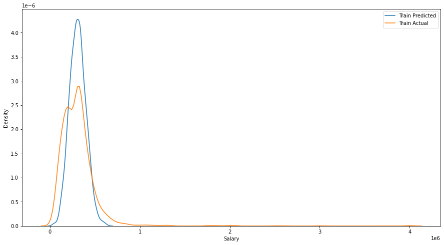

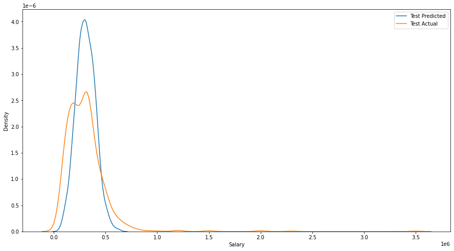

```python
fig,axes=plt.subplots(1,1)
sns.distplot(y_pred_train,label='Train Predicted',hist=False)
sns.distplot(y_train_slr,label='Train Actual',hist=False)
plt.legend()

fig,axes=plt.subplots(1,1)
sns.distplot(y_pred_test,label='Test Predicted',hist=False)
sns.distplot(y_test_slr,label='Test Actual',hist=False)
plt.legend()
```

```python
df[['ComputerProgramming',
 'ElectronicsAndSemicon',
 'ComputerScience',
 'MechanicalEngg',
 'ElectricalEngg',
 'TelecomEngg',
 'CivilEngg']].corr()
```

|  | ComputerProgramming | ElectronicsAndSemicon | ComputerScience | MechanicalEngg | ElectricalEngg | TelecomEngg | CivilEngg |
| --- | --- | --- | --- | --- | --- | --- | --- |
| ComputerProgramming | 1.00000 | -0.36949 | 0.25309 | -0.28484 | -0.13824 | -0.24822 | -0.08827 |
| ElectronicsAndSemicon | -0.36949 | 1.00000 | -0.27362 | -0.10941 | 0.03696 | 0.38702 | 0.00283 |
| ComputerScience | 0.25309 | -0.27362 | 1.00000 | -0.12433 | -0.08380 | -0.14805 | -0.05260 |
| MechanicalEngg | -0.28484 | -0.10941 | -0.12433 | 1.00000 | -0.04050 | -0.07093 | 0.07614 |
| ElectricalEngg | -0.13824 | 0.03696 | -0.08380 | -0.04050 | 1.00000 | -0.05147 | -0.02005 |
| TelecomEngg | -0.24822 | 0.38702 | -0.14805 | -0.07093 | -0.05147 | 1.00000 | -0.03148 |
| CivilEngg | -0.08827 | 0.00283 | -0.05260 | 0.07614 | -0.02005 | -0.03148 | 1.00000 |

**Anomaly Rectification**

```python
print('unique values:',df['GraduationYear'].unique())
```

```
unique values: [2011 2012 2014 2016 2013 2010 2015 2009 2017    0 2007]
```

**Anomaly Detected as 0 as a Graduation Year**

```python
df[df['GraduationYear']==0]
```

|  | ID | Salary | Gender | DOB | 10percentage | 10board | 12graduation | 12percentage | 12board | CollegeTier | Degree | Specialization | collegeGPA | CollegeCityTier | CollegeState | GraduationYear | English | Logical | Quant | Domain | ComputerProgramming | ElectronicsAndSemicon | ComputerScience | MechanicalEngg | ElectricalEngg | TelecomEngg | CivilEngg | conscientiousness | agreeableness | … |
| --- | --- | --- | --- | --- | --- | --- | --- | --- | --- | --- | --- | --- | --- | --- | --- | --- | --- | --- | --- | --- | --- | --- | --- | --- | --- | --- | --- | --- | --- | --- |
| 2664 | 794381 | 325000 | m | 1991-12-17 | 89.00000 | cbse | 2010 | 85.20000 | cbse | 2 | B.Tech/B.E. | mechanical engineering | 68.76000 | 0 | Uttar Pradesh | 0 | 695 | 655 | 680 | 0.75538 | 0 | 0 | 0 | 446 | 0 | 0 | 0 | 1.13360 | 0.37890 | … |

**As 12th passout year was 2010 and the student did engineering so we replace the corresponding GraduationYear with 2014 as an assumption**

```python
df.GraduationYear.replace({0:2014},inplace=True)
df[df['ID']==794381]
```

|  | ID | Salary | Gender | DOB | 10percentage | 10board | 12graduation | 12percentage | 12board | CollegeTier | Degree | Specialization | collegeGPA | CollegeCityTier | CollegeState | GraduationYear | English | Logical | Quant | Domain | ComputerProgramming | ElectronicsAndSemicon | ComputerScience | MechanicalEngg | ElectricalEngg | TelecomEngg | CivilEngg | conscientiousness | agreeableness | … |
| --- | --- | --- | --- | --- | --- | --- | --- | --- | --- | --- | --- | --- | --- | --- | --- | --- | --- | --- | --- | --- | --- | --- | --- | --- | --- | --- | --- | --- | --- | --- |
| 2664 | 794381 | 325000 | m | 1991-12-17 | 89.00000 | cbse | 2010 | 85.20000 | cbse | 2 | B.Tech/B.E. | mechanical engineering | 68.76000 | 0 | Uttar Pradesh | 2014 | 695 | 655 | 680 | 0.75538 | 0 | 0 | 0 | 446 | 0 | 0 | 0 | 1.13360 | 0.37890 | … |

### Feature Extraction

**1.from DOB and Graduation Year column**

```python
df['Age']=df['GraduationYear']-df.DOB.dt.year.astype(int)
df.Age.head()
```

```
0    21
1    23
2    22
3    22
4    21
Name: Age, dtype: int64
```

df.Age.dtype

# Checking For Outliers

```python
df.head()
Numerical=df[['ID','Salary','10percentage','12percentage','collegeGPA','English','Logical','Quant','Domain','ComputerProgramming','ElectronicsAndSemicon','ComputerScience','MechanicalEngg','ElectricalEngg','TelecomEngg','CivilEngg','conscientiousness','agreeableness','extraversion','nueroticism','openess_to_experience','Age']]
Numerical.shape[1]
```

```
22
```

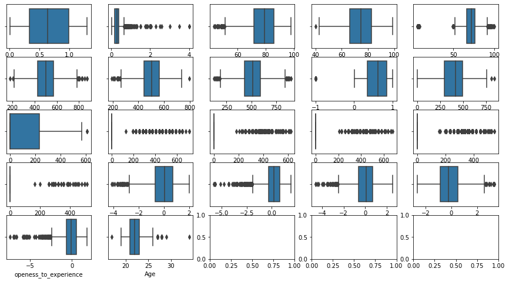

```python
fig, ax = plt.subplots(nrows = 5, ncols = 5, figsize=(15, 8))

for variable, subplot in zip(Numerical.columns, ax.flatten()):

    sns.boxplot(Numerical[variable], ax = subplot)

# display the plot
plt.show()
```

```python
Numerical.skew()
```

```
ID                       0.05477
Salary                   6.45108
10percentage            -0.59102
12percentage            -0.03261
collegeGPA              -1.24921
English                  0.19200
Logical                 -0.21660
Quant                   -0.01940
Domain                  -1.92215
ComputerProgramming     -0.77609
ElectronicsAndSemicon    1.19731
ComputerScience          1.53051
MechanicalEngg           4.03084
ElectricalEngg           5.06204
TelecomEngg              3.04258
CivilEngg               10.31946
conscientiousness       -0.52700
agreeableness           -1.20492
extraversion            -0.52327
nueroticism              0.16571
openess_to_experience   -1.50696
Age                      1.49623
dtype: float64
```

**Interpretation:**

**Highly right skewed data for out Salary(target) column which our genuine outliers as well as MechanicalEngg,Electricalengg,TelecomEngg,CivilEngg containing the marks in the AMCAT tests.**

**So we can transform the Target column while model building to predict**

# Data Cleaning and Preprocessing

#### Preprocessing Gender column

```python
from sklearn.preprocessing import LabelEncoder
LE=LabelEncoder()
df.Gender=LE.fit_transform(df.Gender)
```

```python
df.Gender.unique()
df.Gender.value_counts()
```

```
1    3041
0     957
Name: Gender, dtype: int64
```

```
 [Text(-0.803354993182058, 0.7514125065032227, 'Male'),
 [Text(-0.4381936326447589, 0.40986136718357596, '76.063031'),
```

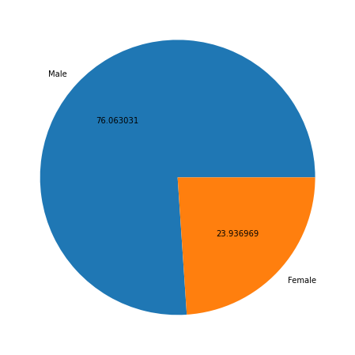

```python
plt.pie(x=df.Gender.value_counts(),labels=['Male','Female'],autopct='%f')
```

#### Cleaning the 10th board column

```python
df['10board'].value_counts()
```

```
cbse                                                                        1395
state board                                                                 1164
0                                                                            350
icse                                                                         281
ssc                                                                          122
up board                                                                      85
matriculation                                                                 38
rbse                                                                          23
board of secondary education                                                  20
up                                                                            19
mp board                                                                      17
sslc                                                                          16
wbbse                                                                         16
central board of secondary education                                          13
kseeb                                                                         12
maharashtra state board                                                       11
upboard                                                                       11
karnataka state board                                                         10
bseb                                                                           9
state                                                                          9
pseb                                                                           8
maharashtra board                                                              8
uttar pradesh board                                                            7
karnataka secondary education examination board                                6
bse                                                                            6
hbse                                                                           6
rajasthan board                                                                6
karnataka secondary education board                                            6
west bengal board of secondary education                                       5
u p board                                                                      5
gseb                                                                           5
bseb,patna                                                                     4
uttar pradesh                                                                  4
uttarakhand board                                                              4
matriculation board                                                            4
secondary school of education                                                  4
mp                                                                             4
stateboard                                                                     4
matric                                                                         4
hbsc                                                                           3
```

[output cut: 221 more lines]

```
delhi public school                                                            1
board of intermediate education                                                1
apsche                                                                         1
andhra pradesh state board                                                     1
board of school education uttarakhand                                          1
board of secondary education,orissa                                            1
karnataka education board                                                      1
mumbai board                                                                   1
karnataka state examination board                                              1
west bengal board of secondary eucation                                        1
board of ssc education andhra pradesh                                          1
bseb patna                                                                     1
kerala state technical education                                               1
cgbse                                                                          1
Name: 10board, dtype: int64
```

```python
print('No of uniques in 10th board column is:',df['10board'].nunique())
```

```
No of uniques in 10th board column is: 275
```

```python
df['10board']=df['10board'].replace({'cbse':'CBSE'})
df['10board']=df['10board'].replace({'central board of secondary education':'CBSE'})
df['10board']=df['10board'].replace({'cbse[gulf zone]':'CBSE'})
df['10board']=df['10board'].replace({'cbsc':'CBSE'})
df['10board']=df['10board'].replace({'central board of secondary education, new delhi':'CBSE'})
df['10board']=df['10board'].replace({'cbse board':'CBSE'})
df['10board']=df['10board'].replace({'delhi public school':'CBSE'})
df['10board']=df['10board'].replace({'dav public school,hehal':'CBSE'})
df['10board']=df['10board'].replace({'aisse':'CBSE'})
df['10board']=df['10board'].replace({'dav public school sec 14'})
```

```python
df['10board']=df['10board'].replace({'icse':'ICSE'})
df['10board']=df['10board'].replace({'icse board':'ICSE'})
df['10board']=df['10board'].replace({'cicse':'ICSE'})
df['10board']=df['10board'].replace({'icse board , new delhi':'ICSE'})
df['10board']=df['10board'].replace({'council for indian school certificate examination':'ICSE'})
df['10board']=df['10board'].replace({'anglo indian':'ICSE'})
```

```python
df['10board']=df['10board'].replace({'certificate of middle years program of ib':'IB'})
```

```python
for i in range(len(df['10board'])):
    if df['10board'][i]!='CBSE' and df['10board'][i]!='ICSE' and df['10board'][i]!='IB':
        df['10board'][i]='STATE BOARD'
```

```python
df['10board'].unique()
```

```
array(['STATE BOARD', 'CBSE', 'ICSE', 'IB'], dtype=object)
```

#### Cleaning the 12thboard column

```python
df['12board'].unique()
```

```
array(['board of intermediate education,ap', 'cbse', 'state board',
       'mp board', 'isc', 'icse', 'karnataka pre university board', 'up',
       'p u board, karnataka', 'dept of pre-university education', 'bie',
       'kerala state hse board', 'up board', 0, 'bseb', 'chse', 'puc',
       ' upboard',
       'state  board of intermediate education, andhra pradesh',
       'karnataka state board',
       'west bengal state council of technical education', 'wbchse',
       'maharashtra state board', 'ssc', 'isc board',
       'sda matric higher secondary school', 'uttar pradesh board', 'ibe',
       'chsc', 'board of intermediate', 'isce', 'upboard', 'sbtet',
       'hisher seconadry examination(state board)', 'pre university',
       'borad of intermediate', 'j & k board',
       'intermediate board of andhra pardesh', 'rbse',
       'central board of secondary education', 'jkbose', 'hbse',
       'board of intermediate education', 'state', 'ms board', 'pue',
       'intermediate state board', 'stateboard', 'hsc',
       'electonincs and communication(dote)', 'karnataka pu board',
       'government polytechnic mumbai , mumbai board', 'pu board',
       'baord of intermediate education', 'apbie', 'andhra board',
       'tamilnadu stateboard',
       'west bengal council of higher secondary education',
       'cbse,new delhi', 'u p board', 'intermediate', 'biec,patna',
       'diploma in engg (e &tc) tilak maharashtra vidayapeeth',
       'hsc pune', 'pu board karnataka', 'kerala', 'gsheb',
       'up(allahabad)', 'nagpur', 'st joseph hr sec school',
       'pre university board', 'ipe', 'maharashtra', 'kea', 'apsb',
       'himachal pradesh board of school education', 'staae board',
       'international baccalaureate (ib) diploma', 'nios',
       'karnataka board of university',
       'board of secondary education rajasthan', 'uttarakhand board',
       'ua', 'scte vt orissa', 'matriculation',
       'department of pre-university education', 'wbscte',
       'preuniversity board(karnataka)', 'jharkhand accademic council',
       'bieap', 'msbte (diploma in computer technology)',
       'jharkhand acamedic council (ranchi)',
       'department of pre-university eduction', 'biec', 'all india board',
       'sjrcw', ' board of intermediate', 'msbte',
       'sri sankara vidyalaya', 'chse, odisha', 'bihar board',
       'maharashtra state(latur board)', 'rajasthan board', 'mpboard',
```

[output cut: 112 more lines]

```
       'maharashtra state board of secondary & higher secondary education',
       'biec, patna', 'state syllabus', 'cbse board', 'scte&vt',
       'board of intermediate,ap',
       'secnior secondary education board of rajasthan',
       'maharashtra board, pune', 'rbse (state board)',
       'board of intermidiate education,ap',
       'board of high school and intermediate education uttarpradesh',
       'higher secondary education',
       'board fo intermediate education, ap', 'intermedite',
       'ap board for intermediate education', 'ahsec',
       'punjab state board of technical education & industrial training, chandigarh',
       'state board - tamilnadu', 'jharkhand acedemic council',
       'scte & vt (diploma)', 'karnataka pu',
       'board of intmediate education ap', 'up-board',
       'boardofintermediate'], dtype=object)
```

```python
print('No of uniques in 12th board column is:',df['12board'].nunique())
```

```
No of uniques in 12th board column is: 340
```

```python
df['12board']=df['12board'].replace({'cbse':'CBSE'})
df['12board']=df['12board'].replace({'central board of secondary education':'CBSE'})
df['12board']=df['12board'].replace({'cbsc':'CBSE'})
df['12board']=df['12board'].replace({'cbse,new delhi':'CBSE'})
df['12board']=df['12board'].replace({'central board of secondary education, new delhi':'CBSE'})
df['12board']=df['12board'].replace({'cbse board':'CBSE'})
df['12board']=df['12board'].replace({'dav public school,hehal':'CBSE'})
df['12board']=df['12board'].replace({'dav public school':'CBSE'})
df['12board']=df['12board'].replace({'dav public school sec 14'})
```

```python
df['12board']=df['12board'].replace({'isc':'ICSE'})
df['12board']=df['12board'].replace({'icse':'ICSE'})
df['12board']=df['12board'].replace({'isc board':'ICSE'})
df['12board']=df['12board'].replace({'cicse':'ICSE'})
df['12board']=df['12board'].replace({'isc board , new delhi':'ICSE'})
df['12board']=df['12board'].replace({'council for indian school certificate examination':'ICSE'})
```

```python
df['12board']=df['12board'].replace({'ibe':'IB'})
df['12board']=df['12board'].replace({'international baccalaureate (ib) diploma':'IB'})
```

```python
for i in range(len(df['12board'])):
    if df['12board'][i]!='CBSE' and df['12board'][i]!='ICSE' and df['12board'][i]!='IB':
        df['12board'][i]='STATE BOARD'
```

```python
df['12board'].unique()
```

```
array(['STATE BOARD', 'CBSE', 'ICSE', 'IB'], dtype=object)
```

# Statistical Data Analysis

# Hypothesis Testing

**Null Hypothesis:Ho: The boards and the class(10th and 12th ) are independent.**

**Alternate Hypothesis:Ha: The boards and the class(10th and 12th ) are Dependent.**

```python
C1=pd.DataFrame({'10board':df['10board'].value_counts().values,
             '12board':df['12board'].value_counts().values},index=df['10board'].value_counts().index)

table=C1.T
table
```

|  | STATE BOARD | CBSE | ICSE | IB |
| --- | --- | --- | --- | --- |
| 10board | 2293 | 1416 | 288 | 1 |
| 12board | 2399 | 1418 | 178 | 3 |

```python
import scipy.stats as stats
from scipy.stats import chi2_contingency
from scipy.stats import chi2
from scipy.stats import chisquare
```

```python
chi2_val = np.abs(round(stats.chi2.isf(q = 0.05, df =3), 4))

print('Critical value for chi-square test:', chi2_val)

test_stat, p, dof, expected_value = chi2_contingency(observed = table, correction = False)

print("Test statistic:", test_stat)
print()
print("p-value:", p)
print()
print("Degrees of freedom:", dof)
print()
print("Expected values:", expected_value)

print()

if test_stat>chi2_val:
    print('We reject the null Hypothesis:Both the dimensions are dependent')
else:
    print('We fail to reject the null hypothesis :Both the dimensions are Independent')
```

```
Critical value for chi-square test: 7.8147
Test statistic: 29.36179107615773

p-value: 1.8797484191531139e-06

Degrees of freedom: 3

Expected values: [[2.346e+03 1.417e+03 2.330e+02 2.000e+00]
 [2.346e+03 1.417e+03 2.330e+02 2.000e+00]]

We reject the null Hypothesis:Both the dimensions are dependent
```

**Interpretation :We can remove one of the above 2 columns as they are HIGHLY CORRELATED and giving the same info to very much extent and contributing the same thing to the model**

**So to reduce the multicollinearity we remove one of them in the later half while model building**

## To clean the specialization column

```python
print('No of uniques in Specialization column is:',df['Specialization'].nunique())

df['Specialization'].value_counts()
```

```
No of uniques in Specialization column is: 46
```

```
electronics and communication engineering      880
computer science & engineering                 744
information technology                         660
computer engineering                           600
computer application                           244
mechanical engineering                         201
electronics and electrical engineering         196
electronics & telecommunications               121
electrical engineering                          82
electronics & instrumentation eng               32
civil engineering                               29
information science engineering                 27
electronics and instrumentation engineering     27
instrumentation and control engineering         20
electronics engineering                         19
biotechnology                                   15
other                                           13
industrial & production engineering             10
chemical engineering                             9
applied electronics and instrumentation          9
computer science and technology                  6
telecommunication engineering                    6
mechanical and automation                        5
automobile/automotive engineering                5
mechatronics                                     4
instrumentation engineering                      4
electronics and computer engineering             3
aeronautical engineering                         3
industrial engineering                           2
metallurgical engineering                        2
biomedical engineering                           2
information & communication technology           2
electrical and power engineering                 2
computer science                                 2
power systems and automation                     1
information science                              1
embedded systems technology                      1
industrial & management engineering              1
control and instrumentation engineering          1
ceramic engineering                              1
electronics                                      1
computer and communication engineering           1
computer networking                              1
internal combustion engine                       1
mechanical & production engineering              1
polymer technology                               1
Name: Specialization, dtype: int64
```

```python
df.Specialization = df.Specialization.replace(['computer science & engineering','computer application','electronics and computer engineering','computer science and technology','software engineering','computer science','computer engineering','electronics and computer engineering'],'computer science and engineering')

df.Specialization = df.Specialization.replace(['electronics','electronics engineering','electronics and telecommunication engineering','electronics and instrumentation engineering','communication engineering'],'electronics and communication engineering')

df.Specialization = df.Specialization.replace(['electronics & instrumentation eng','applied electronics and instrumentation','instrumentation engineering'],'electronics and instrumentation engineering')

df.Specialization = df.Specialization.replace(['telecommunication engineering','electronics and telecommunication','electronics & telecommunications'],'electronics and telecommunication engineering')

df.Specialization = df.Specialization.replace(['information science engineering','information science','information & communication technology'],'information technology')

df.Specialization = df.Specialization.replace(['industrial & production engineering','industrial engineering and management'],'industrial and production engineering')

df.Specialization = df.Specialization.replace('other','Others')
```

```python
print(df['Specialization'].nunique())

df['Specialization'].value_counts()
```

```
32
```

```
computer science and engineering                 1599
electronics and communication engineering         927
information technology                            690
mechanical engineering                            201
electronics and electrical engineering            196
electronics and telecommunication engineering     127
electrical engineering                             82
electronics and instrumentation engineering        45
civil engineering                                  29
instrumentation and control engineering            20
biotechnology                                      15
Others                                             13
industrial and production engineering              10
chemical engineering                                9
automobile/automotive engineering                   5
mechanical and automation                           5
mechatronics                                        4
aeronautical engineering                            3
industrial engineering                              2
biomedical engineering                              2
metallurgical engineering                           2
electrical and power engineering                    2
computer and communication engineering              1
embedded systems technology                         1
power systems and automation                        1
control and instrumentation engineering             1
industrial & management engineering                 1
mechanical & production engineering                 1
ceramic engineering                                 1
internal combustion engine                          1
polymer technology                                  1
computer networking                                 1
Name: Specialization, dtype: int64
```

**The specialization whose count is less than 10 , We try to combine or bin to the 'other' Specialization**

```python
less_freq_specialization=df['Specialization'].value_counts()[df['Specialization'].value_counts()<10]

to_be_replaced=list(less_freq_specialization.index)

df.Specialization = df.Specialization.replace(to_be_replaced,'Others')

df.Specialization.value_counts()

#binn electronics
```

```
computer science and engineering                 1599
electronics and communication engineering         927
information technology                            690
mechanical engineering                            201
electronics and electrical engineering            196
electronics and telecommunication engineering     127
electrical engineering                             82
Others                                             57
electronics and instrumentation engineering        45
civil engineering                                  29
instrumentation and control engineering            20
biotechnology                                      15
industrial and production engineering              10
Name: Specialization, dtype: int64
```

**Checking The Degree Column**

```python
df.Degree.unique()
```

```
array(['B.Tech/B.E.', 'MCA', 'M.Tech./M.E.', 'M.Sc. (Tech.)'],
      dtype=object)
```

```python
df.Degree.value_counts()
```

```
B.Tech/B.E.      3700
MCA               243
M.Tech./M.E.       53
M.Sc. (Tech.)       2
Name: Degree, dtype: int64
```

**To find which students have a drop in their academics : we create a column Gap in Education**

```python
Yeardiff=df['GraduationYear']-df['12graduation']

Yeardiff.head()
```

```
0    4
1    5
2    4
3    4
4    4
dtype: int64
```

```python
df['Gap_in_Education']=0
```

```python
for i in range(len(df)) :

    if df['Degree'][i]=='MCA' and Yeardiff[i]<=5 :
        df['Gap_in_Education'][i]=0
    elif df['Degree'][i]=='B.Tech/B.E.' and Yeardiff[i]<=4  :
        df['Gap_in_Education'][i]=0
    elif df['Degree'][i]=='M.Tech./M.E.' and Yeardiff[i]<=6:
        df['Gap_in_Education'][i]=0
    elif df['Degree'][i]=='M.Sc. (Tech.)' and Yeardiff[i]<=5:
        df['Gap_in_Education'][i]=0
    else:
        df['Gap_in_Education'][i]=1
```

```python
df['Gap_in_Education'].head()
```

```
0    0
1    1
2    0
3    0
4    0
Name: Gap_in_Education, dtype: int64
```

### Number of students who had a Gap in their Education

```
 [Text(-0.6532409858657606, 1.1239556105047606, 'No gap'),
 [Text(-0.4019944528404681, 0.6916649910798527, '66.758376'),
```

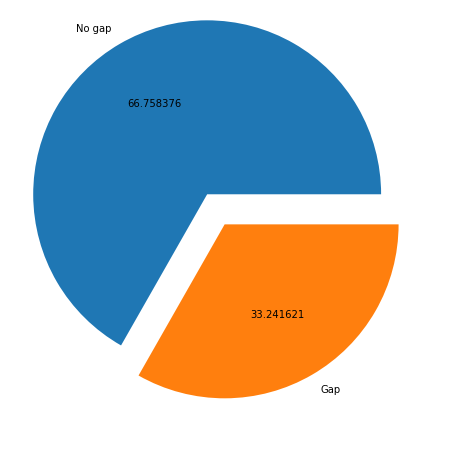

```python
plt.pie(x=df['Gap_in_Education'].value_counts(),labels=['No gap','Gap'],autopct='%f',explode=[0.2,0])
```

**Interpretation: Approx 1/3 of the total data of students had a Gap in their Education**

## Averge Salary of the students depending they had Gap in education or not

```python
df.groupby('Gap_in_Education')['Salary'].mean()
```

```
Gap_in_Education
0   306929.18696
1   309247.55455
Name: Salary, dtype: float64
```

```python
df.GraduationYear.value_counts().sort_values(ascending=False)
```

```
2013    1181
2014    1037
2012     847
2011     507
2010     292
2015      94
2009      24
2017       8
2016       7
2007       1
Name: GraduationYear, dtype: int64
```

**Interpretation: The average salary came about to be similar depending about the gap in education**

### Number of Students who Graduated in Each Year

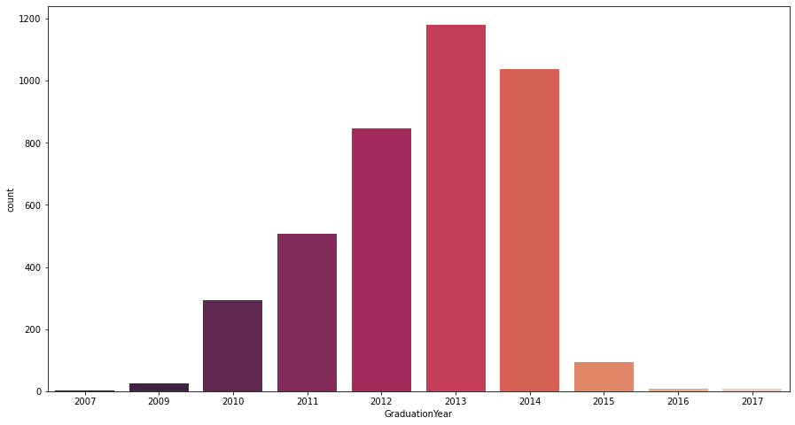

```python
sns.countplot(df.GraduationYear,palette='rocket')
```

### Average Salary depending upon the completion of Graduation

```python
df.groupby('GraduationYear')['Salary'].mean().sort_values()
```

```
GraduationYear
2007   120000.00000
2017   195625.00000
2014   267979.74928
2013   277810.33023
2016   295714.28571
2015   299574.46809
2012   315478.15821
2009   365625.00000
2011   369684.41815
2010   441318.49315
Name: Salary, dtype: float64
```

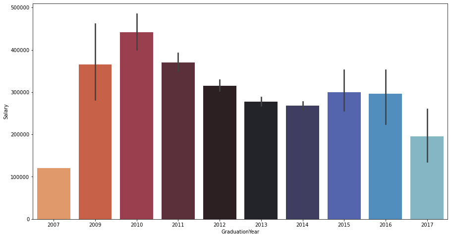

```python
sns.barplot(x=df.GraduationYear,y=df.Salary,palette='icefire_r')
```

**Interpretation:2010 followed by 2011 and 2009 students had the highest avg salary as compared to the other students who did graduation in other years**

### Average salary of students each year on the basis of College Tier

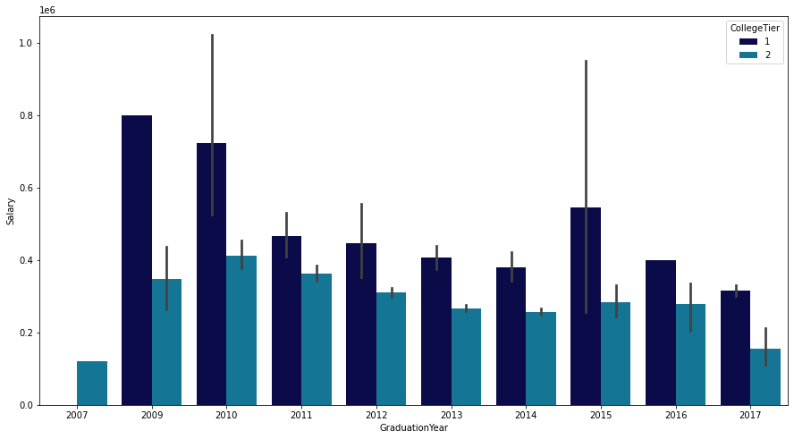

```python
sns.barplot(x=df.GraduationYear,y=df.Salary,hue=df.CollegeTier,palette='ocean')
```

**Interpretation:**

**3.The highest average salary was of the students who did graduation in 2009 but as there is no confidence in the bars it clearly depicts there must be few students in college tier 1 in 2009 so the highest average salary was of the students who graduated in 2010 from college tier1**

# Analysis using Visualisation

### Correlation between Numerical Variables

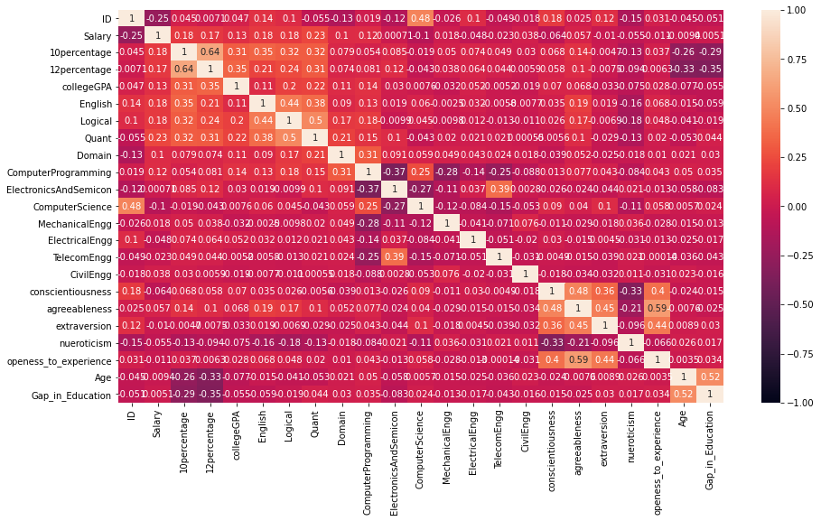

```python
sns.heatmap(df.iloc[:,[0,1,4,7,12,16,17,18,19,20,21,22,23,24,25,26,27,28,29,30,31,32,33]].corr(),annot=True,vmin=-1,vmax=1)
```

**Interpretation: No column has a strong correlation with the target column**

## Distribution of Target Column

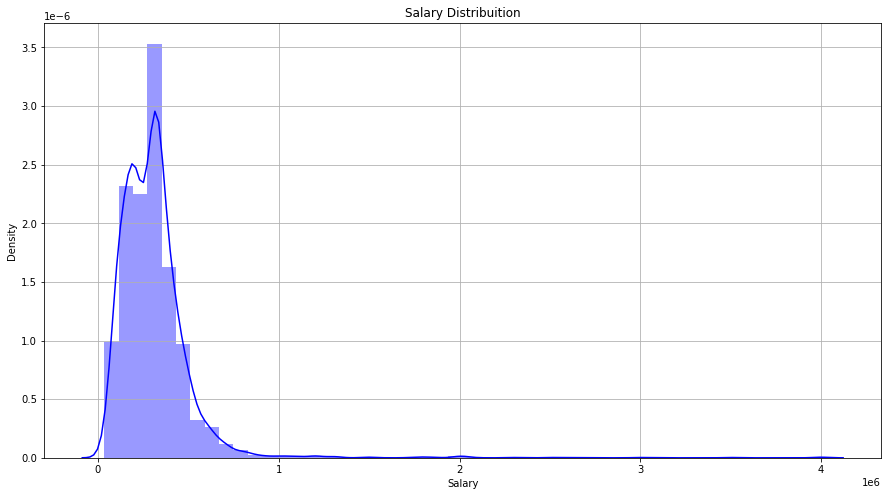

```python
plt.grid()
sns.distplot(df['Salary'],color='b')
plt.title('Salary Distribuition')
```

**Interpretation: The target column is highly skewed**

**Hence we can use the transformation techniques while model building if the assumptions dont meet up to the mark**

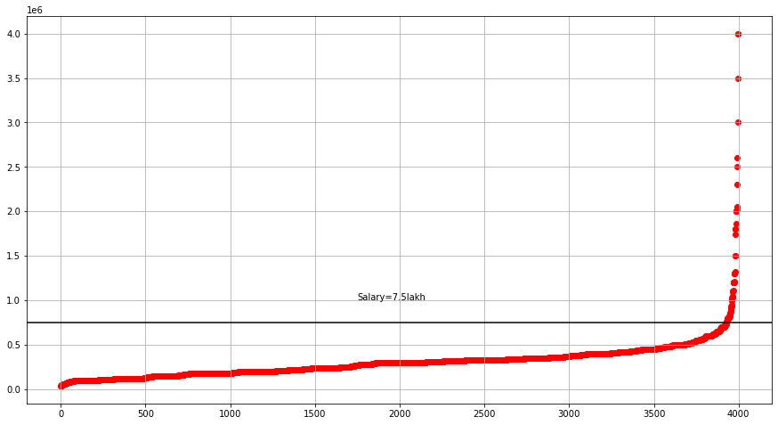

```python
plt.scatter(x=range(len(df)),y=df.Salary.sort_values(),color='red')
plt.axhline(y=750000,color='black')
plt.text(x=1750,y=1000000,s='Salary=7.5lakh')
plt.grid()
```

**Interpretation:As the Density of points is higher below the black line we can infer that Most of the Students are having salary less than 7.5lac lpa mark.**

### Number of students who had a Gap in their Education

```
 [Text(-0.6532409858657606, 1.1239556105047606, 'No gap'),
 [Text(-0.4019944528404681, 0.6916649910798527, '66.758376'),
```

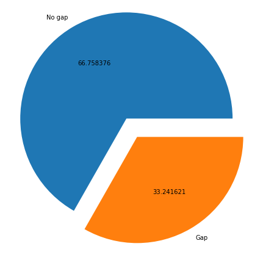

```python
plt.pie(x=df['Gap_in_Education'].value_counts(),labels=['No gap','Gap'],autopct='%f',explode=[0.2,0])
```

**Interpretation: Approx 1/3 of the total data of students had a Gap in their Education**

## Averge Salary of the students depending they had Gap in education or not

```python
df.groupby('Gap_in_Education')['Salary'].mean()
```

```
Gap_in_Education
0   306929.18696
1   309247.55455
Name: Salary, dtype: float64
```

**Interpretation: The average salary came about to be similar depending about the gap in education**

### Number of Students who Graduated in Each Year

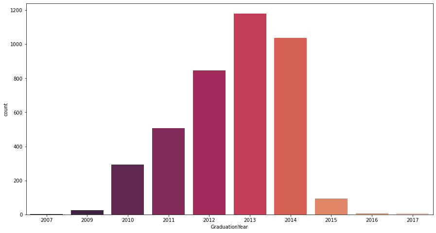

```python
sns.countplot(df.GraduationYear,palette='rocket')
```

### Average Salary depending upon the completion of Graduation

```python
df.groupby('GraduationYear')['Salary'].mean().sort_values()
```

```
GraduationYear
2007   120000.00000
2017   195625.00000
2014   267979.74928
2013   277810.33023
2016   295714.28571
2015   299574.46809
2012   315478.15821
2009   365625.00000
2011   369684.41815
2010   441318.49315
Name: Salary, dtype: float64
```

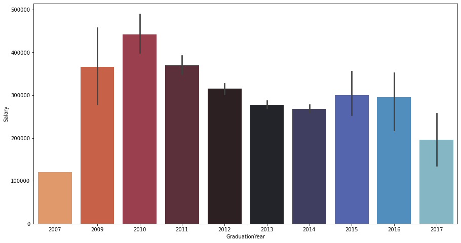

```python
sns.barplot(x=df.GraduationYear,y=df.Salary,palette='icefire_r')
```

**Interpretation:2010 followed by 2011 and 2009 students had the highest avg salary as compared to the other students who did graduation in other years**

### Average salary of students each year on the basis of College Tier

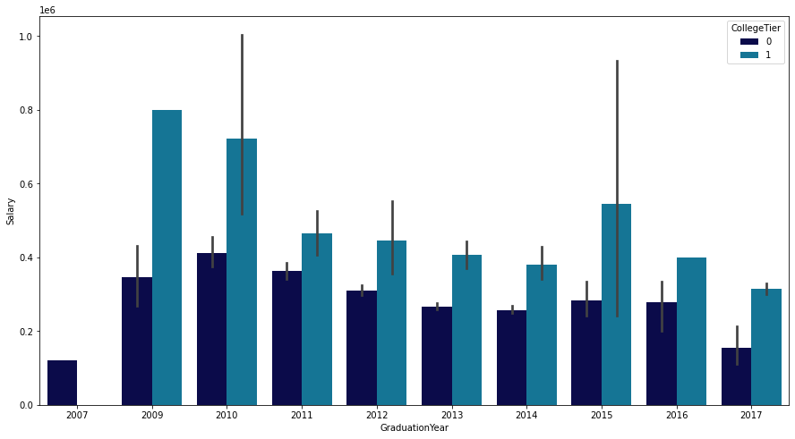

```python
sns.barplot(x=df.GraduationYear,y=df.Salary,hue=df.CollegeTier,palette='ocean')
```

**Interpretation:**

**2.The average salary of students who belonged to college tier 1 was high in each year as expected from the college tier 0**

**3.The highest average salary was of the students who did graduation in 2009 but as there is no confidence in the bars it clearly depicts there must be few students in college tier 1 in 2009 so the highest average salary was of the students who graduated in 2010 from college tier1**

## Distribution of Salary on the basis of Gender

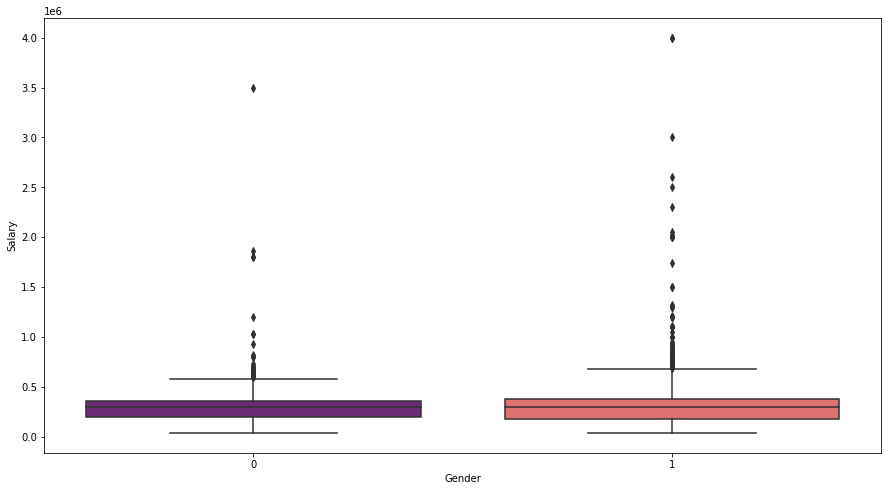

```python
sns.boxplot(x=df.Gender,y=df.Salary,palette='magma')
```

**The distribution of salary for male and female are similiar to each other having similar salary as quartiles, The number of students earning more than the 3rd whisker is more in males(1) as compared to female(0).**

**Hence most of the students earning salary more than 10lac mark are males**

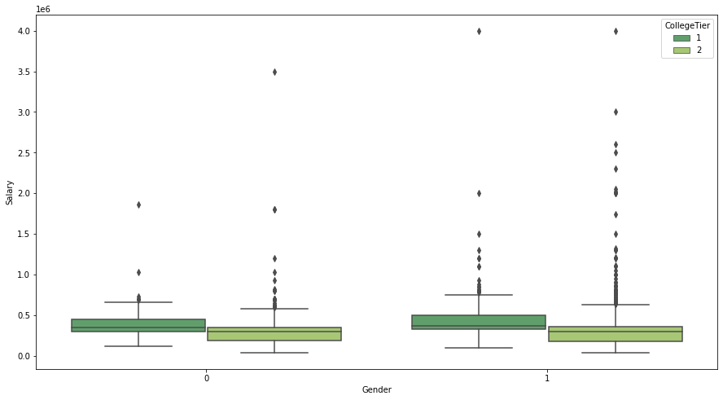

```python
sns.boxplot(x=df.Gender,y=df.Salary,hue=df.CollegeTier,palette='summer')
```

**Interpretation:Both in Males and Females The salary distribution from college tier 1 is higher than the college tier 2.**

### Distribution of Salary Column on the basis of College Tier

```python
df['CollegeTier'].value_counts()
```

```
2    3701
1     297
Name: CollegeTier, dtype: int64
```

```python
df['CollegeTier']=df['CollegeTier'].replace({2:0})

df['CollegeTier'].value_counts()
```

```
0    3701
1     297
Name: CollegeTier, dtype: int64
```

**College tier 2 count is 3701 i.e middle level facility colleges and College tier 1 count is 297i.e high level facility colleges**

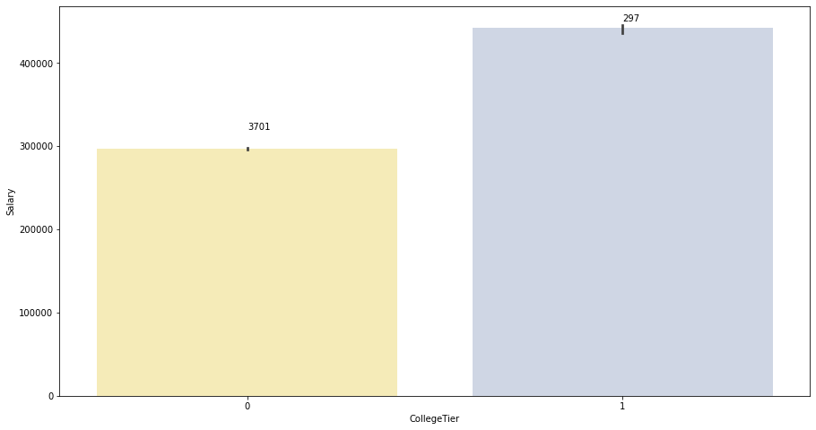

```python
sns.barplot(y=df.Salary,x=df['CollegeTier'],ci=20,palette='Pastel2_r')

plt.text(x=1.001,y=450000,s=df['CollegeTier'].value_counts()[1])
plt.text(y=320000,x=0.001,s=df['CollegeTier'].value_counts()[0])
```

**Interpretation:Although the count of Premium and Middle level colleges are imbalanced but the average Salary of the students from Premium colleges is higher than the average salary of the students from Middle level facility colleges**

### Strength of 10th percentage column and 12th percentage column on the basis of college Tier

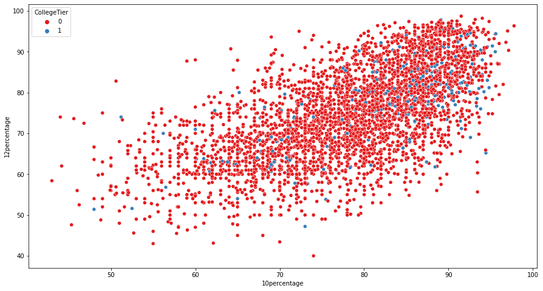

```python
sns.scatterplot(df['10percentage'],df['12percentage'],hue=df['CollegeTier'],palette='Set1')
```

**Interpretation:Most blue points are clustered in the top right corner that indicates Most of the college students from Tier1 have got good Percentage of marks both in 10th and 12th.**

### Distribution of Salary on the basis of CollegeCity Tier

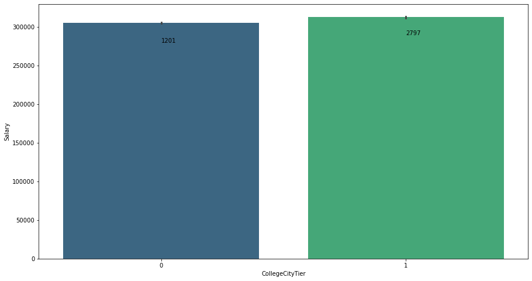

```python
sns.barplot(y=df.Salary,x=df['CollegeCityTier'],ci=20,palette='viridis')

plt.text(x=1.001,y=290000,s=df['CollegeCityTier'].value_counts()[0])
plt.text(y=280000,x=0.001,s=df['CollegeCityTier'].value_counts()[1])
```

**CollegeCityTier has no effect on Salary as the mean salary from both the city tier are almost same:depicted by the barplot**

**Hence we can drop the column while model building**

### Salary distribution on the basis of Degree

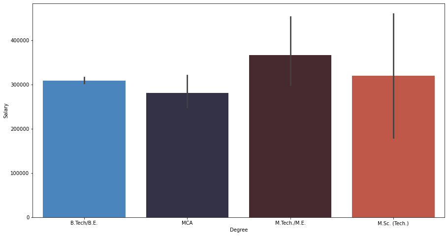

```python
sns.barplot(x=df.Degree,y=df.Salary,palette='icefire')
```

**Inference: The average salary of the Mtech students is highest followed by Msc and Btech**

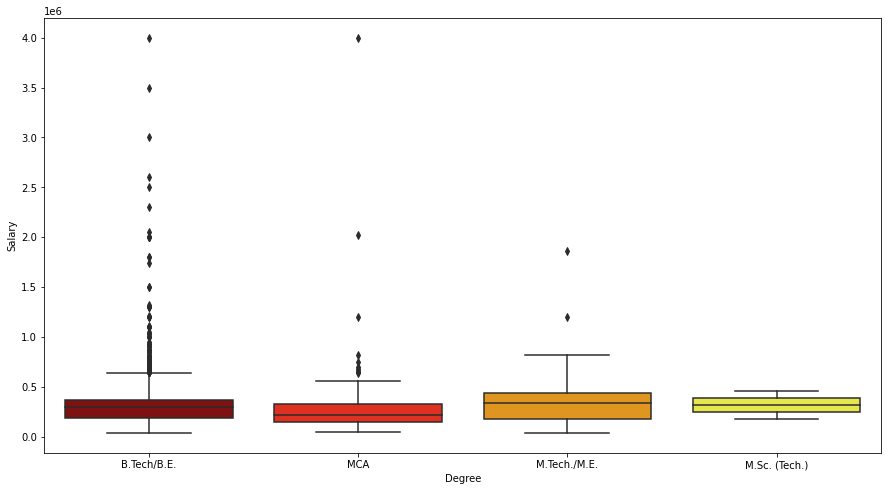

```python
sns.boxplot(x=df.Degree,y=df.Salary,palette='hot')
```

**Inference:Though the average salary is higher for Mtech students but the outliers or the no of students with higher salary is greater who has done Btech/B.E.**

### Salary distribution on the basis of Specialization of the students the did their graduation in.

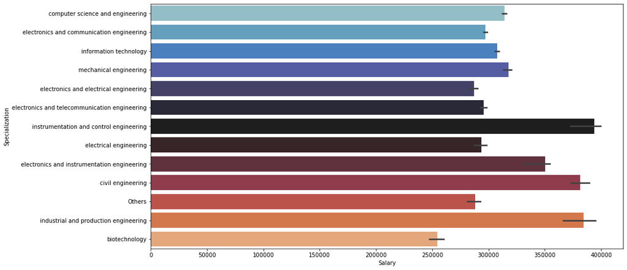

```python
sns.barplot(y=df['Specialization'],x=df.Salary,ci=20,palette='icefire')
```

**Inference:The average salary is highest of the stuendts who pursued instrumentation and control engineering followed by industrial and**

**production engineering whereas the lowest average salary is of the students who did Biotechnology**

### Distribution of Salary on the basis of specialization and College Tier

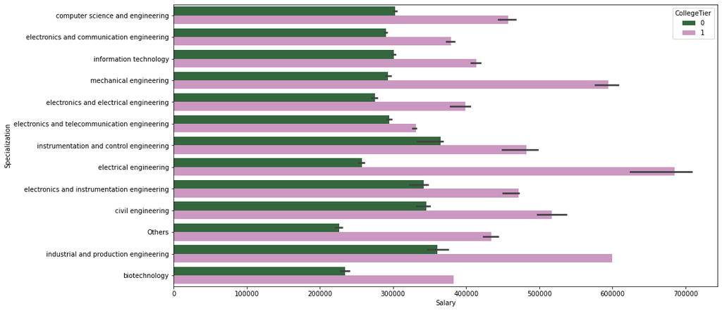

```python
sns.barplot(y=df['Specialization'],x=df.Salary,ci=20,hue=df.CollegeTier,palette='cubehelix')
```

**Inference:In all the Specialization the average Salary of students is higher who have done their graduation from College Tier1(Premium Colleges)**

### Distribution of Salary on the basis of Degree and college Tier

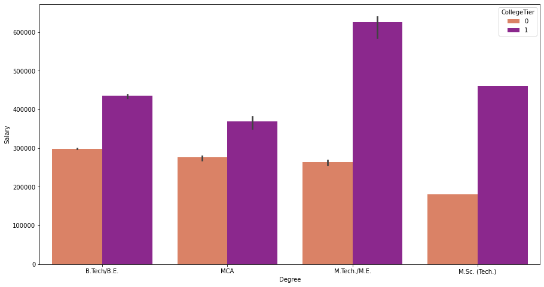

```python
sns.barplot(y=df.Salary,x=df['Degree'],ci=20,hue=df.CollegeTier,palette='plasma_r')
```

**Inference:Students from all the degrees having passed out from College Tier 1 has higher avg salary as compared to the later one**

## Distribution of Salary with respect to Specialization

```python
df.groupby(['Specialization'])['Salary'].describe().iloc[:,[1,3,5,7]].sort_values(by='max',ascending=True)
```

| Specialization | mean | min | 50% | max |
| --- | --- | --- | --- | --- |
| biotechnology | 254333.33333 | 100000.00000 | 235000.00000 | 450000.00000 |
| electronics and telecommunication engineering | 295866.14173 | 45000.00000 | 300000.00000 | 630000.00000 |
| industrial and production engineering | 384500.00000 | 170000.00000 | 382500.00000 | 660000.00000 |
| Others | 288245.61404 | 100000.00000 | 300000.00000 | 730000.00000 |
| civil engineering | 381206.89655 | 110000.00000 | 320000.00000 | 800000.00000 |
| instrumentation and control engineering | 394000.00000 | 150000.00000 | 312500.00000 | 1300000.00000 |
| mechanical engineering | 317457.71144 | 60000.00000 | 275000.00000 | 1300000.00000 |
| electrical engineering | 293780.48780 | 40000.00000 | 300000.00000 | 1860000.00000 |
| information technology | 307681.15942 | 35000.00000 | 300000.00000 | 2000000.00000 |
| electronics and instrumentation engineering | 350222.22222 | 100000.00000 | 300000.00000 | 2300000.00000 |
| electronics and electrical engineering | 286913.26531 | 45000.00000 | 280000.00000 | 2500000.00000 |
| electronics and communication engineering | 297071.19741 | 40000.00000 | 300000.00000 | 3000000.00000 |
| computer science and engineering | 313949.34334 | 35000.00000 | 300000.00000 | 4000000.00000 |

**Inference:**

**2.Whereas the highest average salary is o those students who have opted Instumetation & control engineering and industrial and production engineering**

**3.The minimum salary of the overall students students comes from IT and CSE as well**

### Distribution of Salary on the basis of States of the students they belong to.

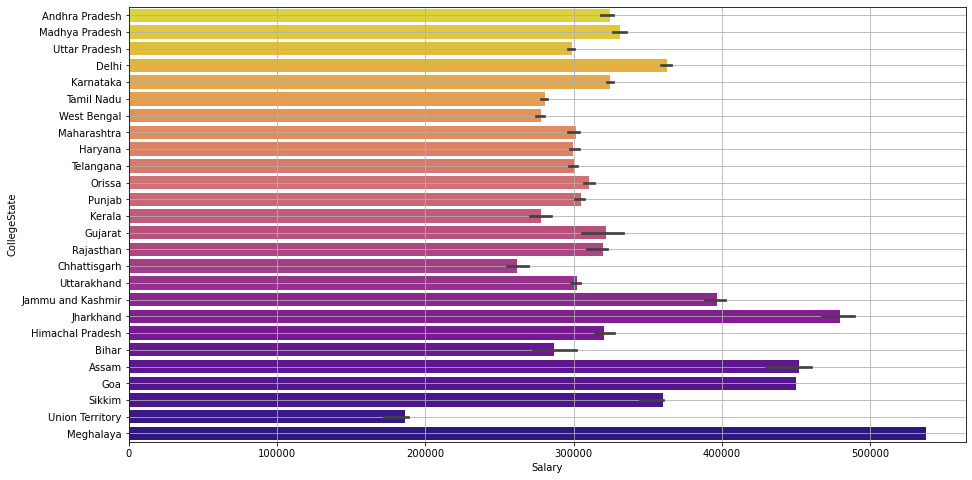

```python
sns.barplot(y=df['CollegeState'],x=df.Salary,ci=20,palette='plasma_r')
plt.grid()
```

**Interpretation:Graduates from Meghalaya,Jharkhand,Assam respectively have the higher mean Salary**

**whereas**

**Chattisgarh and the union territories have the lowest mean salary of the graduates**

### Average of Salary with respect to States on the basis of College Tier

```python
#check for rajasthan students
```

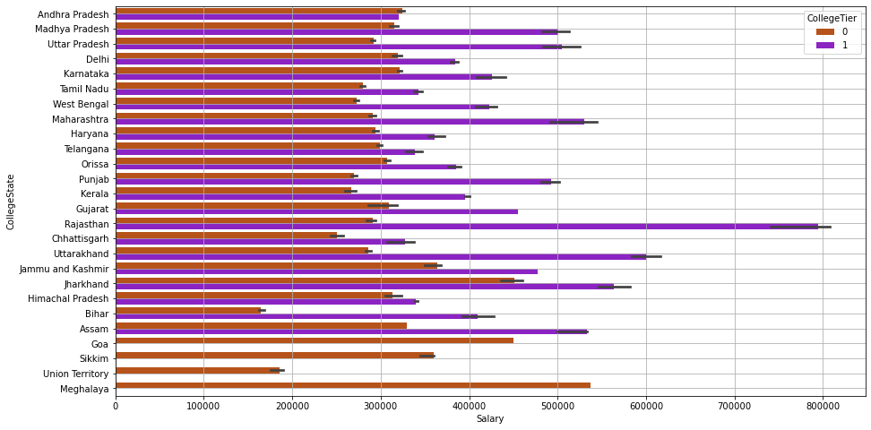

```python
sns.barplot(y=df['CollegeState'],x=df.Salary,hue=df.CollegeTier,ci=20,palette='gnuplot_r')
plt.grid()
```

**Interpretation:**

**1.Andhra Pradhesh Students of College Tier 0 has greater avwrage salary than the premium college students salary.**

**2.All the other states have the same trend which we have got till now- The average salary of the students from Premium Colleges are higher than the Middle Facility colleges**

**3.Out of all the states ,students from Rajasthan which are from premium colleges have the Highest average salary among all the states with respect to any college tier they belong to.**

**4.Few States like Goa ,Sikkim,Meghalaya and Union Territory doesnt have any premium colleges**

### College Count Tier wise in each state

```python
TierWise_data=df.groupby(['CollegeTier'])['CollegeState'].value_counts()
College_count=pd.DataFrame({'Tier0':TierWise_data[0].sort_index(),
             'Tier1':TierWise_data[1].sort_index()})
College_count.sort_values('Tier1')
```

|  | Tier0 | Tier1 |
| --- | --- | --- |
| Andhra Pradesh | 224 | 1.00000 |
| Gujarat | 22 | 2.00000 |
| Jammu and Kashmir | 5 | 2.00000 |
| Assam | 2 | 3.00000 |
| Kerala | 30 | 3.00000 |
| Chhattisgarh | 23 | 4.00000 |
| Himachal Pradesh | 12 | 4.00000 |
| Bihar | 5 | 5.00000 |
| Tamil Nadu | 362 | 5.00000 |
| Uttarakhand | 107 | 6.00000 |
| Orissa | 165 | 7.00000 |
| West Bengal | 189 | 7.00000 |
| Jharkhand | 21 | 7.00000 |
| Telangana | 310 | 9.00000 |
| Karnataka | 361 | 9.00000 |
| Rajasthan | 164 | 10.00000 |
| Maharashtra | 251 | 11.00000 |
| Haryana | 165 | 15.00000 |
| Madhya Pradesh | 173 | 16.00000 |
| Punjab | 163 | 30.00000 |
| Uttar Pradesh | 884 | 31.00000 |
| Delhi | 52 | 110.00000 |
| Goa | 1 | nan |
| Meghalaya | 2 | nan |
| Sikkim | 3 | nan |
| Union Territory | 5 | nan |

**Interpretation:**

**1.Most have the state have few Tier 1 colleges and high no.of tier 0 colleges**

**2.Delhi has the highest no of Tier1 colleges amongst all the states and UT and also has higher no of tier 1 colleges than tier 0 colleges it has.**

### Salary Distribution on the basis of Age of the Students

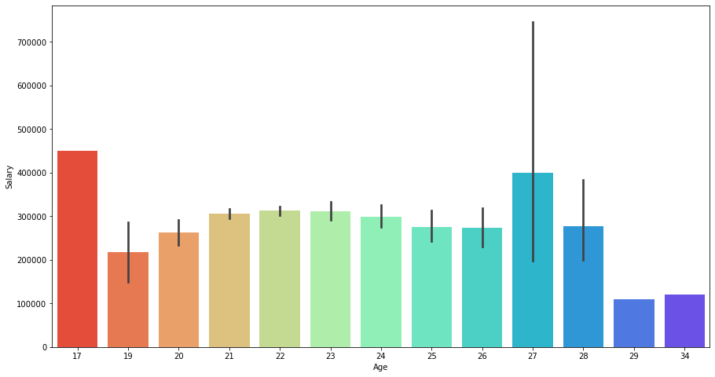

```python
sns.barplot(x=df.Age,y=df.Salary,ci=95,palette='rainbow_r')
```

**Interpretation:The Average Salary of Students of Age 27 is higher as compared to other students.**

**The salary of student of age 17 is higher because their is only 1student at Age 17**

# OLS Model

```python
df.head()
```

|  | ID | Salary | Gender | DOB | 10percentage | 10board | 12graduation | 12percentage | 12board | CollegeTier | Degree | Specialization | collegeGPA | CollegeCityTier | CollegeState | GraduationYear | English | Logical | Quant | Domain | ComputerProgramming | ElectronicsAndSemicon | ComputerScience | MechanicalEngg | ElectricalEngg | TelecomEngg | CivilEngg | conscientiousness | agreeableness | … |
| --- | --- | --- | --- | --- | --- | --- | --- | --- | --- | --- | --- | --- | --- | --- | --- | --- | --- | --- | --- | --- | --- | --- | --- | --- | --- | --- | --- | --- | --- | --- |
| 0 | 203097 | 420000 | 0 | 1990-02-19 | 84.30000 | STATE BOARD | 2007 | 95.80000 | STATE BOARD | 0 | B.Tech/B.E. | computer science and engineering | 78.00000 | 0 | Andhra Pradesh | 2011 | 515 | 585 | 525 | 0.63598 | 445 | 0 | 0 | 0 | 0 | 0 | 0 | 0.97370 | 0.81280 | … |
| 1 | 579905 | 500000 | 1 | 1989-10-04 | 85.40000 | CBSE | 2007 | 85.00000 | CBSE | 0 | B.Tech/B.E. | electronics and communication engineering | 70.06000 | 0 | Madhya Pradesh | 2012 | 695 | 610 | 780 | 0.96060 | 0 | 466 | 0 | 0 | 0 | 0 | 0 | -0.73350 | 0.37890 | … |
| 2 | 810601 | 325000 | 0 | 1992-08-03 | 85.00000 | CBSE | 2010 | 68.20000 | CBSE | 0 | B.Tech/B.E. | information technology | 70.00000 | 0 | Uttar Pradesh | 2014 | 615 | 545 | 370 | 0.45088 | 395 | 0 | 0 | 0 | 0 | 0 | 0 | 0.27180 | 1.71090 | … |
| 3 | 267447 | 1100000 | 1 | 1989-12-05 | 85.60000 | CBSE | 2007 | 83.60000 | CBSE | 1 | B.Tech/B.E. | computer science and engineering | 74.64000 | 1 | Delhi | 2011 | 635 | 585 | 625 | 0.97440 | 615 | 0 | 0 | 0 | 0 | 0 | 0 | 0.04640 | 0.34480 | … |
| 4 | 343523 | 200000 | 1 | 1991-02-27 | 78.00000 | CBSE | 2008 | 76.80000 | CBSE | 0 | B.Tech/B.E. | electronics and communication engineering | 73.90000 | 0 | Uttar Pradesh | 2012 | 545 | 625 | 465 | 0.12450 | 0 | 233 | 0 | 0 | 0 | 0 | 0 | -0.88100 | -0.27930 | … |

```python
#dummify ,collegecity tier
```

```python
DF=df.drop(['ID','DOB','10board','12graduation','GraduationYear','CollegeCityTier'],axis=1)
DF.head()
```

|  | Salary | Gender | 10percentage | 12percentage | 12board | CollegeTier | Degree | Specialization | collegeGPA | CollegeState | English | Logical | Quant | Domain | ComputerProgramming | ElectronicsAndSemicon | ComputerScience | MechanicalEngg | ElectricalEngg | TelecomEngg | CivilEngg | conscientiousness | agreeableness | extraversion | nueroticism | openess_to_experience | Age | Gap_in_Education |
| --- | --- | --- | --- | --- | --- | --- | --- | --- | --- | --- | --- | --- | --- | --- | --- | --- | --- | --- | --- | --- | --- | --- | --- | --- | --- | --- | --- | --- |
| 0 | 420000 | 0 | 84.30000 | 95.80000 | STATE BOARD | 0 | B.Tech/B.E. | computer science and engineering | 78.00000 | Andhra Pradesh | 515 | 585 | 525 | 0.63598 | 445 | 0 | 0 | 0 | 0 | 0 | 0 | 0.97370 | 0.81280 | 0.52690 | 1.35490 | -0.44550 | 21 | 0 |
| 1 | 500000 | 1 | 85.40000 | 85.00000 | CBSE | 0 | B.Tech/B.E. | electronics and communication engineering | 70.06000 | Madhya Pradesh | 695 | 610 | 780 | 0.96060 | 0 | 466 | 0 | 0 | 0 | 0 | 0 | -0.73350 | 0.37890 | 1.23960 | -0.10760 | 0.86370 | 23 | 1 |
| 2 | 325000 | 0 | 85.00000 | 68.20000 | CBSE | 0 | B.Tech/B.E. | information technology | 70.00000 | Uttar Pradesh | 615 | 545 | 370 | 0.45088 | 395 | 0 | 0 | 0 | 0 | 0 | 0 | 0.27180 | 1.71090 | 0.16370 | -0.86820 | 0.67210 | 22 | 0 |
| 3 | 1100000 | 1 | 85.60000 | 83.60000 | CBSE | 1 | B.Tech/B.E. | computer science and engineering | 74.64000 | Delhi | 635 | 585 | 625 | 0.97440 | 615 | 0 | 0 | 0 | 0 | 0 | 0 | 0.04640 | 0.34480 | -0.34400 | -0.40780 | -0.91940 | 22 | 0 |
| 4 | 200000 | 1 | 78.00000 | 76.80000 | CBSE | 0 | B.Tech/B.E. | electronics and communication engineering | 73.90000 | Uttar Pradesh | 545 | 625 | 465 | 0.12450 | 0 | 233 | 0 | 0 | 0 | 0 | 0 | -0.88100 | -0.27930 | -1.06970 | 0.09163 | -0.12950 | 21 | 0 |

```python
DF_num=DF.iloc[:,[0,2,3,8,10,11,12,13,14,15,16,17,18,19,20,21,22,23,24,25,26]]
DF_cat=pd.get_dummies(DF.iloc[:,[1,4,5,6,7,9,27]],drop_first=True)
```

```python
DF_num.shape,DF_cat.shape
```

```
((3998, 21), (3998, 46))
```

```python
X_num=DF_num.drop('Salary',axis=1)
X_cat=DF_cat

X=pd.concat([X_num,X_cat],axis=1)
```

```python
X=sm.add_constant(X)

Y=DF_num.Salary

X.shape,Y.shape
```

```
((3998, 67), (3998,))
```

```python
X_train_slr, X_test_slr, y_train_slr, y_test_slr = train_test_split(X, (Y),random_state=0, test_size = 0.3)

SLR_model1 = sm.OLS(y_train_slr, X_train_slr).fit()
# print the summary output
SLR_model1.summary()
```

OLS Regression Results

| Dep. Variable: | Salary | R-squared: | 0.188 |
| --- | --- | --- | --- |
| Model: | OLS | Adj. R-squared: | 0.169 |
| Method: | Least Squares | F-statistic: | 9.589 |
| Date: | Wed, 26 Jan 2022 | Prob (F-statistic): | 2.01e-82 |
| Time: | 19:10:20 | Log-Likelihood: | -37602. |
| No. Observations: | 2798 | AIC: | 7.534e+04 |
| Df Residuals: | 2731 | BIC: | 7.574e+04 |
| Df Model: | 66 |  |  |
| Covariance Type: | nonrobust |  |  |

|  | coef | std err | t | P>\|t\| | [0.025 | 0.975] |
| --- | --- | --- | --- | --- | --- | --- |
| const | -1.831e+05 | 1.03e+05 | -1.781 | 0.075 | -3.85e+05 | 1.84e+04 |
| 10percentage | 517.1937 | 482.893 | 1.071 | 0.284 | -429.679 | 1464.066 |
| 12percentage | 1662.3866 | 477.281 | 3.483 | 0.001 | 726.518 | 2598.256 |
| collegeGPA | 2154.8409 | 476.988 | 4.518 | 0.000 | 1219.548 | 3090.134 |
| English | 114.8800 | 37.349 | 3.076 | 0.002 | 41.645 | 188.115 |
| Logical | 49.4399 | 46.123 | 1.072 | 0.284 | -40.999 | 139.879 |
| Quant | 194.8865 | 34.269 | 5.687 | 0.000 | 127.690 | 262.083 |
| Domain | 1.398e+04 | 9453.634 | 1.479 | 0.139 | -4556.556 | 3.25e+04 |
| ComputerProgramming | 35.7728 | 22.228 | 1.609 | 0.108 | -7.814 | 79.359 |
| ElectronicsAndSemicon | 7.3466 | 40.142 | 0.183 | 0.855 | -71.366 | 86.059 |
| ComputerScience | -154.3723 | 19.908 | -7.754 | 0.000 | -193.409 | -115.335 |
| MechanicalEngg | -10.9205 | 81.485 | -0.134 | 0.893 | -170.699 | 148.858 |
| ElectricalEngg | -155.7649 | 52.122 | -2.988 | 0.003 | -257.968 | -53.562 |
| TelecomEngg | -2.4319 | 36.550 | -0.067 | 0.947 | -74.100 | 69.236 |
| CivilEngg | 448.0035 | 194.334 | 2.305 | 0.021 | 66.947 | 829.060 |
| conscientiousness | -1.799e+04 | 3889.947 | -4.624 | 0.000 | -2.56e+04 | -1.04e+04 |
| agreeableness | 1.056e+04 | 4737.436 | 2.230 | 0.026 | 1272.934 | 1.99e+04 |
| extraversion | 4544.6027 | 4034.065 | 1.127 | 0.260 | -3365.525 | 1.25e+04 |
| nueroticism | -7823.6702 | 3530.944 | -2.216 | 0.027 | -1.47e+04 | -900.079 |
| openess_to_experience | -8531.4452 | 4101.912 | -2.080 | 0.038 | -1.66e+04 | -488.281 |
| Age | -4711.8597 | 3616.381 | -1.303 | 0.193 | -1.18e+04 | 2379.260 |
| Gender | 2.042e+04 | 8045.017 | 2.538 | 0.011 | 4640.127 | 3.62e+04 |
| CollegeTier | 1.142e+05 | 1.52e+04 | 7.489 | 0.000 | 8.43e+04 | 1.44e+05 |
| Gap_in_Education | -471.7529 | 8808.462 | -0.054 | 0.957 | -1.77e+04 | 1.68e+04 |
| 12board_IB | -1.047e+05 | 1.7e+05 | -0.614 | 0.539 | -4.39e+05 | 2.3e+05 |
| 12board_ICSE | 2.632e+04 | 1.64e+04 | 1.605 | 0.109 | -5826.940 | 5.85e+04 |
| 12board_STATE BOARD | 7202.5700 | 8714.551 | 0.826 | 0.409 | -9885.209 | 2.43e+04 |
| Degree_M.Sc. (Tech.) | 4.021e+04 | 1.22e+05 | 0.329 | 0.742 | -1.99e+05 | 2.8e+05 |
| Degree_M.Tech./M.E. | 4.958e+04 | 2.8e+04 | 1.770 | 0.077 | -5352.217 | 1.05e+05 |
| Degree_MCA | 8412.8635 | 1.66e+04 | 0.507 | 0.612 | -2.41e+04 | 4.1e+04 |
| Specialization_biotechnology | 3.063e+04 | 6.15e+04 | 0.498 | 0.618 | -8.99e+04 | 1.51e+05 |
| Specialization_civil engineering | -1.148e+05 | 9.12e+04 | -1.258 | 0.208 | -2.94e+05 | 6.41e+04 |
| Specialization_computer science and engineering | 4.687e+04 | 3.33e+04 | 1.408 | 0.159 | -1.84e+04 | 1.12e+05 |
| Specialization_electrical engineering | 4.725e+04 | 4.04e+04 | 1.168 | 0.243 | -3.21e+04 | 1.27e+05 |
| Specialization_electronics and communication engineering | 1.569e+04 | 3.21e+04 | 0.489 | 0.625 | -4.72e+04 | 7.85e+04 |
| Specialization_electronics and electrical engineering | 3.419e+04 | 3.57e+04 | 0.957 | 0.338 | -3.58e+04 | 1.04e+05 |
| Specialization_electronics and instrumentation engineering | 4.302e+04 | 4.26e+04 | 1.009 | 0.313 | -4.06e+04 | 1.27e+05 |
| Specialization_electronics and telecommunication engineering | 2.453e+04 | 3.69e+04 | 0.665 | 0.506 | -4.78e+04 | 9.69e+04 |
| Specialization_industrial and production engineering | 4.309e+04 | 7.7e+04 | 0.559 | 0.576 | -1.08e+05 | 1.94e+05 |
| Specialization_information technology | 5.801e+04 | 3.36e+04 | 1.724 | 0.085 | -7953.589 | 1.24e+05 |
| Specialization_instrumentation and control engineering | 9.203e+04 | 5.62e+04 | 1.637 | 0.102 | -1.82e+04 | 2.02e+05 |
| Specialization_mechanical engineering | 3.516e+04 | 3.96e+04 | 0.887 | 0.375 | -4.26e+04 | 1.13e+05 |
| CollegeState_Assam | 4.293e+05 | 1.71e+05 | 2.512 | 0.012 | 9.41e+04 | 7.64e+05 |
| CollegeState_Bihar | -1.004e+05 | 5.92e+04 | -1.696 | 0.090 | -2.17e+05 | 1.57e+04 |
| CollegeState_Chhattisgarh | 5617.8444 | 4.3e+04 | 0.131 | 0.896 | -7.87e+04 | 8.99e+04 |
| CollegeState_Delhi | -3.686e+04 | 2.49e+04 | -1.482 | 0.138 | -8.56e+04 | 1.19e+04 |
| CollegeState_Goa | 1.061e+05 | 1.73e+05 | 0.612 | 0.540 | -2.34e+05 | 4.46e+05 |
| CollegeState_Gujarat | 2.156e+04 | 4.72e+04 | 0.457 | 0.648 | -7.09e+04 | 1.14e+05 |
| CollegeState_Haryana | 1.915e+04 | 2.21e+04 | 0.866 | 0.386 | -2.42e+04 | 6.25e+04 |
| CollegeState_Himachal Pradesh | 1.786e+04 | 5.2e+04 | 0.343 | 0.731 | -8.41e+04 | 1.2e+05 |
| CollegeState_Jammu and Kashmir | -1.792e+04 | 7.74e+04 | -0.232 | 0.817 | -1.7e+05 | 1.34e+05 |
| CollegeState_Jharkhand | 9.684e+04 | 4.16e+04 | 2.327 | 0.020 | 1.52e+04 | 1.78e+05 |
| CollegeState_Karnataka | 5.718e+04 | 1.85e+04 | 3.091 | 0.002 | 2.09e+04 | 9.35e+04 |
| CollegeState_Kerala | -3.167e+04 | 3.89e+04 | -0.815 | 0.415 | -1.08e+05 | 4.46e+04 |
| CollegeState_Madhya Pradesh | 3.594e+04 | 2.15e+04 | 1.670 | 0.095 | -6263.954 | 7.81e+04 |
| CollegeState_Maharashtra | 2.035e+04 | 2.02e+04 | 1.008 | 0.314 | -1.92e+04 | 5.99e+04 |
| CollegeState_Meghalaya | 2.587e+04 | 1.7e+05 | 0.153 | 0.879 | -3.07e+05 | 3.58e+05 |
| CollegeState_Orissa | 2.975e+04 | 2.26e+04 | 1.319 | 0.187 | -1.45e+04 | 7.4e+04 |
| CollegeState_Punjab | -9426.6603 | 2.25e+04 | -0.419 | 0.675 | -5.35e+04 | 3.46e+04 |
| CollegeState_Rajasthan | 1.028e+04 | 2.16e+04 | 0.476 | 0.634 | -3.2e+04 | 5.26e+04 |
| CollegeState_Sikkim | 1.578e+04 | 1.21e+05 | 0.131 | 0.896 | -2.21e+05 | 2.52e+05 |
| CollegeState_Tamil Nadu | -1.453e+04 | 1.75e+04 | -0.829 | 0.407 | -4.89e+04 | 1.98e+04 |
| CollegeState_Telangana | -1.111e+04 | 1.79e+04 | -0.622 | 0.534 | -4.61e+04 | 2.39e+04 |
| CollegeState_Union Territory | -7.841e+04 | 8.56e+04 | -0.916 | 0.360 | -2.46e+05 | 8.95e+04 |
| CollegeState_Uttar Pradesh | 2.256e+04 | 1.74e+04 | 1.300 | 0.194 | -1.15e+04 | 5.66e+04 |
| CollegeState_Uttarakhand | 9055.3936 | 2.48e+04 | 0.365 | 0.715 | -3.96e+04 | 5.77e+04 |
| CollegeState_West Bengal | -8185.6083 | 2.15e+04 | -0.380 | 0.704 | -5.04e+04 | 3.4e+04 |

| Omnibus: | 3543.883 | Durbin-Watson: | 2.010 |
| --- | --- | --- | --- |
| Prob(Omnibus): | 0.000 | Jarque-Bera (JB): | 1288090.262 |
| Skew: | 6.508 | Prob(JB): | 0.00 |
| Kurtosis: | 107.304 | Cond. No. | 5.35e+04 |

Notes:  
[1] Standard Errors assume that the covariance matrix of the errors is correctly specified.  
[2] The condition number is large, 5.35e+04. This might indicate that there are  
strong multicollinearity or other numerical problems.

```python
y_pred_train=SLR_model1.predict(X_train_slr)

y_pred_test=SLR_model1.predict(X_test_slr)
```

```python
SLR_model1_Rsq=(SLR_model1.rsquared)

SLR_model1_Rsq_adj=SLR_model1.rsquared_adj

SLR_model1_train_rmse=np.sqrt(mean_squared_error(y_train_slr,y_pred_train))

SLR_model_test_rmse=np.sqrt(mean_squared_error(y_test_slr,y_pred_test))
```

```python
print('Model R2 is:',(SLR_model1.rsquared))
print()
print('Model Adjusted R2 is:',SLR_model1.rsquared_adj)
print()
print('RMSE on train data with base model is:', np.sqrt(mean_squared_error(y_train_slr,y_pred_train)))
print()
print('RMSE on test data with base model is:',np.sqrt(mean_squared_error(y_test_slr,y_pred_test)))
```

```
Model R2 is: 0.1881388914137575

Model Adjusted R2 is: 0.1685186668928157

RMSE on train data with base model is: 166033.9329325507

RMSE on test data with base model is: 258676.24593450074
```

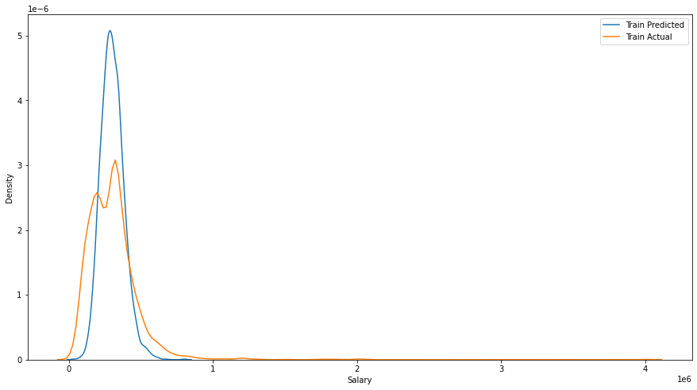

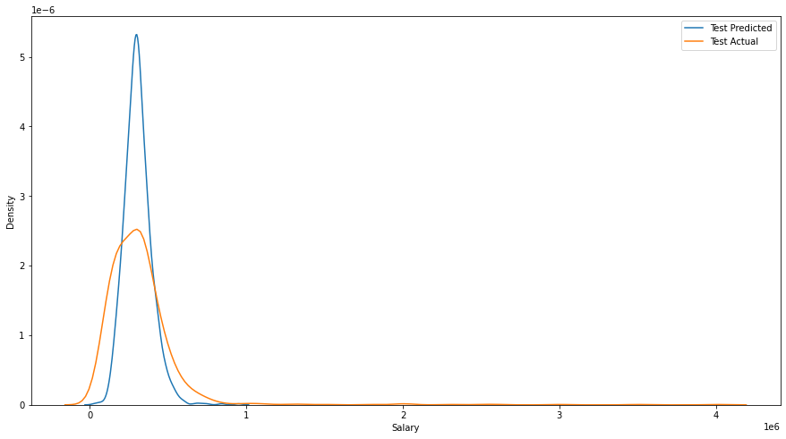

```python
fig,axes=plt.subplots(1,1)
sns.distplot(y_pred_train,label='Train Predicted',hist=False)
sns.distplot(y_train_slr,label='Train Actual',hist=False)
plt.legend()

fig,axes=plt.subplots(1,1)
sns.distplot(y_pred_test,label='Test Predicted',hist=False)
sns.distplot(y_test_slr,label='Test Actual',hist=False)
plt.legend()
```

**Since The target Column is skewed and is not normal so we transform the column and put it into the model**

```python
X_train_slr, X_test_slr, y_train_slr, y_test_slr = train_test_split(X, np.log(Y),random_state=0, test_size = 0.3)

SLR_model2 = sm.OLS(y_train_slr, X_train_slr).fit()
# print the summary output
SLR_model2.summary()
```

OLS Regression Results

| Dep. Variable: | Salary | R-squared: | 0.266 |
| --- | --- | --- | --- |
| Model: | OLS | Adj. R-squared: | 0.249 |
| Method: | Least Squares | F-statistic: | 15.03 |
| Date: | Wed, 26 Jan 2022 | Prob (F-statistic): | 9.54e-138 |
| Time: | 19:10:21 | Log-Likelihood: | -1776.6 |
| No. Observations: | 2798 | AIC: | 3687. |
| Df Residuals: | 2731 | BIC: | 4085. |
| Df Model: | 66 |  |  |
| Covariance Type: | nonrobust |  |  |

|  | coef | std err | t | P>\|t\| | [0.025 | 0.975] |
| --- | --- | --- | --- | --- | --- | --- |
| const | 10.5582 | 0.283 | 37.357 | 0.000 | 10.004 | 11.112 |
| 10percentage | 0.0027 | 0.001 | 2.007 | 0.045 | 6.09e-05 | 0.005 |
| 12percentage | 0.0062 | 0.001 | 4.738 | 0.000 | 0.004 | 0.009 |
| collegeGPA | 0.0082 | 0.001 | 6.278 | 0.000 | 0.006 | 0.011 |
| English | 0.0005 | 0.000 | 4.917 | 0.000 | 0.000 | 0.001 |
| Logical | 9.745e-05 | 0.000 | 0.768 | 0.442 | -0.000 | 0.000 |
| Quant | 0.0008 | 9.42e-05 | 8.013 | 0.000 | 0.001 | 0.001 |
| Domain | 0.0488 | 0.026 | 1.878 | 0.061 | -0.002 | 0.100 |
| ComputerProgramming | 0.0001 | 6.11e-05 | 2.418 | 0.016 | 2.79e-05 | 0.000 |
| ElectronicsAndSemicon | -8.107e-05 | 0.000 | -0.734 | 0.463 | -0.000 | 0.000 |
| ComputerScience | -0.0005 | 5.47e-05 | -9.175 | 0.000 | -0.001 | -0.000 |
| MechanicalEngg | -3.029e-05 | 0.000 | -0.135 | 0.892 | -0.000 | 0.000 |
| ElectricalEngg | -0.0005 | 0.000 | -3.209 | 0.001 | -0.001 | -0.000 |
| TelecomEngg | -2.211e-05 | 0.000 | -0.220 | 0.826 | -0.000 | 0.000 |
| CivilEngg | 0.0013 | 0.001 | 2.454 | 0.014 | 0.000 | 0.002 |
| conscientiousness | -0.0446 | 0.011 | -4.172 | 0.000 | -0.066 | -0.024 |
| agreeableness | 0.0257 | 0.013 | 1.970 | 0.049 | 0.000 | 0.051 |
| extraversion | 0.0114 | 0.011 | 1.025 | 0.305 | -0.010 | 0.033 |
| nueroticism | -0.0223 | 0.010 | -2.296 | 0.022 | -0.041 | -0.003 |
| openess_to_experience | -0.0142 | 0.011 | -1.259 | 0.208 | -0.036 | 0.008 |
| Age | -0.0115 | 0.010 | -1.154 | 0.249 | -0.031 | 0.008 |
| Gender | 0.0581 | 0.022 | 2.625 | 0.009 | 0.015 | 0.101 |
| CollegeTier | 0.2601 | 0.042 | 6.205 | 0.000 | 0.178 | 0.342 |
| Gap_in_Education | 0.0137 | 0.024 | 0.567 | 0.571 | -0.034 | 0.061 |
| 12board_IB | -0.3911 | 0.469 | -0.834 | 0.404 | -1.310 | 0.528 |
| 12board_ICSE | 0.0592 | 0.045 | 1.313 | 0.189 | -0.029 | 0.148 |
| 12board_STATE BOARD | -0.0092 | 0.024 | -0.384 | 0.701 | -0.056 | 0.038 |
| Degree_M.Sc. (Tech.) | 0.2827 | 0.336 | 0.841 | 0.400 | -0.376 | 0.941 |
| Degree_M.Tech./M.E. | 0.0021 | 0.077 | 0.028 | 0.978 | -0.149 | 0.153 |
| Degree_MCA | -0.0600 | 0.046 | -1.314 | 0.189 | -0.149 | 0.030 |
| Specialization_biotechnology | 0.1142 | 0.169 | 0.676 | 0.499 | -0.217 | 0.446 |
| Specialization_civil engineering | -0.3109 | 0.251 | -1.239 | 0.215 | -0.803 | 0.181 |
| Specialization_computer science and engineering | 0.1122 | 0.092 | 1.226 | 0.220 | -0.067 | 0.292 |
| Specialization_electrical engineering | 0.1059 | 0.111 | 0.952 | 0.341 | -0.112 | 0.324 |
| Specialization_electronics and communication engineering | 0.0709 | 0.088 | 0.805 | 0.421 | -0.102 | 0.244 |
| Specialization_electronics and electrical engineering | 0.0769 | 0.098 | 0.783 | 0.434 | -0.116 | 0.269 |
| Specialization_electronics and instrumentation engineering | 0.1929 | 0.117 | 1.645 | 0.100 | -0.037 | 0.423 |
| Specialization_electronics and telecommunication engineering | 0.1090 | 0.101 | 1.074 | 0.283 | -0.090 | 0.308 |
| Specialization_industrial and production engineering | 0.1370 | 0.212 | 0.647 | 0.518 | -0.278 | 0.552 |
| Specialization_information technology | 0.1682 | 0.093 | 1.819 | 0.069 | -0.013 | 0.350 |
| Specialization_instrumentation and control engineering | 0.2508 | 0.155 | 1.622 | 0.105 | -0.052 | 0.554 |
| Specialization_mechanical engineering | 0.0399 | 0.109 | 0.366 | 0.714 | -0.174 | 0.254 |
| CollegeState_Assam | 1.0456 | 0.470 | 2.225 | 0.026 | 0.124 | 1.967 |
| CollegeState_Bihar | -0.3469 | 0.163 | -2.130 | 0.033 | -0.666 | -0.028 |
| CollegeState_Chhattisgarh | 0.0110 | 0.118 | 0.093 | 0.926 | -0.221 | 0.243 |
| CollegeState_Delhi | -0.0765 | 0.068 | -1.118 | 0.264 | -0.211 | 0.058 |
| CollegeState_Goa | 0.4023 | 0.477 | 0.844 | 0.399 | -0.532 | 1.337 |
| CollegeState_Gujarat | -0.0732 | 0.130 | -0.564 | 0.573 | -0.328 | 0.181 |
| CollegeState_Haryana | 0.0562 | 0.061 | 0.924 | 0.356 | -0.063 | 0.175 |
| CollegeState_Himachal Pradesh | 0.0900 | 0.143 | 0.629 | 0.529 | -0.191 | 0.370 |
| CollegeState_Jammu and Kashmir | 0.0154 | 0.213 | 0.072 | 0.942 | -0.402 | 0.433 |
| CollegeState_Jharkhand | 0.2299 | 0.114 | 2.009 | 0.045 | 0.006 | 0.454 |
| CollegeState_Karnataka | 0.2082 | 0.051 | 4.092 | 0.000 | 0.108 | 0.308 |
| CollegeState_Kerala | -0.1893 | 0.107 | -1.771 | 0.077 | -0.399 | 0.020 |
| CollegeState_Madhya Pradesh | 0.1027 | 0.059 | 1.734 | 0.083 | -0.013 | 0.219 |
| CollegeState_Maharashtra | 0.0852 | 0.056 | 1.534 | 0.125 | -0.024 | 0.194 |
| CollegeState_Meghalaya | 0.1479 | 0.466 | 0.317 | 0.751 | -0.766 | 1.062 |
| CollegeState_Orissa | 0.0812 | 0.062 | 1.309 | 0.191 | -0.040 | 0.203 |
| CollegeState_Punjab | -0.0216 | 0.062 | -0.349 | 0.727 | -0.143 | 0.100 |
| CollegeState_Rajasthan | 0.0335 | 0.059 | 0.565 | 0.572 | -0.083 | 0.150 |
| CollegeState_Sikkim | 0.1522 | 0.332 | 0.459 | 0.646 | -0.498 | 0.803 |
| CollegeState_Tamil Nadu | -0.0375 | 0.048 | -0.779 | 0.436 | -0.132 | 0.057 |
| CollegeState_Telangana | -0.0373 | 0.049 | -0.760 | 0.447 | -0.134 | 0.059 |
| CollegeState_Union Territory | -0.3121 | 0.235 | -1.325 | 0.185 | -0.774 | 0.150 |
| CollegeState_Uttar Pradesh | 0.0457 | 0.048 | 0.957 | 0.339 | -0.048 | 0.139 |
| CollegeState_Uttarakhand | 0.0377 | 0.068 | 0.553 | 0.580 | -0.096 | 0.171 |
| CollegeState_West Bengal | -0.0581 | 0.059 | -0.982 | 0.326 | -0.174 | 0.058 |

| Omnibus: | 143.812 | Durbin-Watson: | 2.080 |
| --- | --- | --- | --- |
| Prob(Omnibus): | 0.000 | Jarque-Bera (JB): | 511.364 |
| Skew: | -0.102 | Prob(JB): | 9.09e-112 |
| Kurtosis: | 5.084 | Cond. No. | 5.35e+04 |

Notes:  
[1] Standard Errors assume that the covariance matrix of the errors is correctly specified.  
[2] The condition number is large, 5.35e+04. This might indicate that there are  
strong multicollinearity or other numerical problems.

```python
y_pred_train=SLR_model2.predict(X_train_slr)

y_pred_test=SLR_model2.predict(X_test_slr)
```

```python
SLR_model2_Rsq=(SLR_model2.rsquared)

SLR_model2_Rsq_adj=SLR_model2.rsquared_adj

SLR_model2_train_rmse=np.sqrt(mean_squared_error(np.exp(y_train_slr),np.exp(y_pred_train)))

SLR_model2_test_rmse=np.sqrt(mean_squared_error(np.exp(y_test_slr),np.exp(y_pred_test)))
```

```python
print('Model R2 is:',(SLR_model2.rsquared))
print()
print('Model Adjusted R2 is:',SLR_model2.rsquared_adj)
print()
print('RMSE on train data with base model is:',SLR_model2_train_rmse)
print()
print('RMSE on test data with base model is:',SLR_model2_test_rmse)
```

```
Model R2 is: 0.2664355869971844

Model Adjusted R2 is: 0.24870755651084764

RMSE on train data with base model is: 169303.3622890898

RMSE on test data with base model is: 263507.38752422854
```

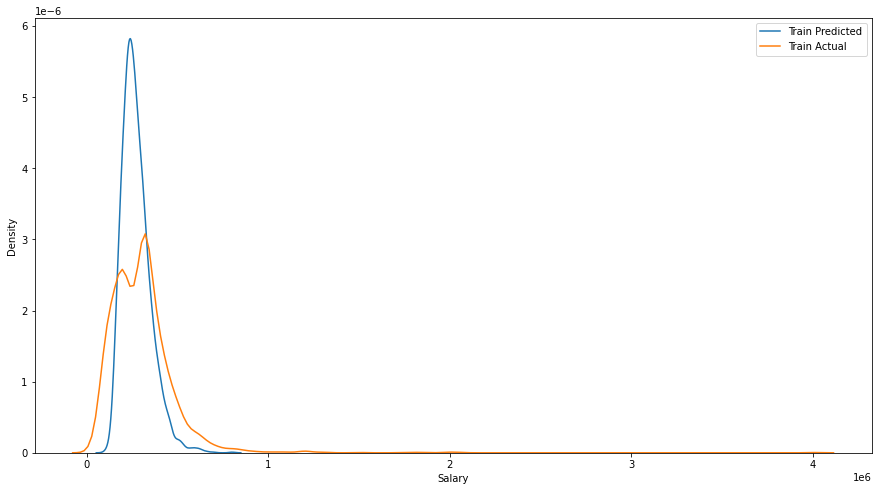

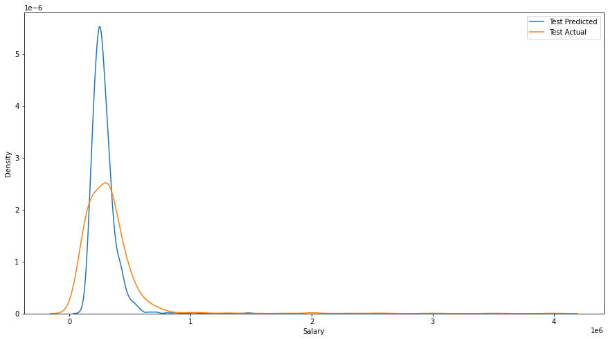

```python
fig,axes=plt.subplots(1,1)
sns.distplot(np.exp(y_pred_train),label='Train Predicted',hist=False)
sns.distplot(np.exp(y_train_slr),label='Train Actual',hist=False)
plt.legend()

fig,axes=plt.subplots(1,1)
sns.distplot(np.exp(y_pred_test),label='Test Predicted',hist=False)
sns.distplot(np.exp(y_test_slr),label='Test Actual',hist=False)
plt.legend()
```